# AIRBNB MILANO TESINA

Sostituisco gli NA dei voti con la mediana, MA il modello di regressione saprà che sono “finti” grazie alla variabile has_reviews.

```r
df_final <- df_pulito %>%
  # Manteniamo solo prezzi sensati (rimuovendo errori di battitura a 0 o lusso estremo)
  # e alloggi dedicati agli affitti brevi turistici (max 30 notti)
  filter(price > 10 & price < 800) %>%
  filter(minimum_nights <= 30) %>%

  # IMPUTAZIONE DATI STRUTTURALI
  # Utilizzo la mediana per non distorcere le distribuzioni delle variabili
  # di conteggio discrete (letti, camere, bagni) in presenza di NA.
  mutate(
    bedrooms = ifelse(is.na(bedrooms), median(bedrooms, na.rm = TRUE), bedrooms),
    beds = ifelse(is.na(beds), median(beds, na.rm = TRUE), beds),
    bathrooms = ifelse(is.na(bathrooms), median(bathrooms, na.rm = TRUE), bathrooms)
  ) %>%

  # GESTIONE E IMPUTAZIONE RECENSIONI
  mutate(
    # Creo una Dummy: VERO se l'host ha già ricevuto valutazioni, FALSO altrimenti.
    has_reviews = ifelse(is.na(review_scores_rating), FALSE, TRUE),

    # Imputiamo tutti i punteggi mancanti con la loro rispettiva mediana.
    review_scores_rating = ifelse(is.na(review_scores_rating), median(review_scores_rating, na.rm = TRUE), review_scores_rating),
    review_scores_accuracy = ifelse(is.na(review_scores_accuracy), median(review_scores_accuracy, na.rm = TRUE), review_scores_accuracy),
    review_scores_cleanliness = ifelse(is.na(review_scores_cleanliness), median(review_scores_cleanliness, na.rm = TRUE), review_scores_cleanliness),
    review_scores_checkin = ifelse(is.na(review_scores_checkin), median(review_scores_checkin, na.rm = TRUE), review_scores_checkin),
    review_scores_communication = ifelse(is.na(review_scores_communication), median(review_scores_communication, na.rm = TRUE), review_scores_communication),
    review_scores_location = ifelse(is.na(review_scores_location), median(review_scores_location, na.rm = TRUE), review_scores_location),
    review_scores_value = ifelse(is.na(review_scores_value), median(review_scores_value, na.rm = TRUE), review_scores_value)
  ) %>%

  #IMPUTAZIONE SUPERHOST
  # Stimo lo status di Superhost utilizzando i dati di rating ed esperienza.
  mutate(
    host_is_superhost = case_when(
      # Se esiste, lo lascio così
      !is.na(host_is_superhost) ~ host_is_superhost,

      # Se è NA, testo voto eccezionale e buona esperienza
      is.na(host_is_superhost) & review_scores_rating >= 4.8 & number_of_reviews >= 10 ~ TRUE,

      # Per tutti gli altri NA che non soddisfano i requisiti di eccellenza, assegno FALSE
      TRUE ~ FALSE
    )
  )

# Controllo
summary(df_final)
```

```
##      price     host_is_superhost     room_type      accommodates
##  Min.   : 16   Mode :logical     Length   :17020   Min.   : 1.000
##  1st Qu.: 91   FALSE:10916       N.unique :    4   1st Qu.: 2.000
##  Median :125   TRUE :6104        N.blank  :    0   Median : 4.000
##  Mean   :155                     Min.nchar:   10   Mean   : 3.462
##  3rd Qu.:184                     Max.nchar:   15   3rd Qu.: 4.000
##  Max.   :793                                       Max.   :16.000
##     bedrooms           beds        neighbourhood_cleansed    latitude
##  Min.   : 0.000   Min.   : 0.000   Length   :17020        Min.   :45.40
##  1st Qu.: 1.000   1st Qu.: 1.000   N.unique :   86        1st Qu.:45.46
##  Median : 1.000   Median : 2.000   N.blank  :    0        Median :45.47
##  Mean   : 1.204   Mean   : 1.906   Min.nchar:    4        Mean   :45.47
##  3rd Qu.: 1.000   3rd Qu.: 2.000   Max.nchar:   28        3rd Qu.:45.49
##  Max.   :10.000   Max.   :20.000                          Max.   :45.54
##    longitude     number_of_reviews review_scores_rating review_scores_accuracy
##  Min.   :9.067   Min.   :   0.00   Min.   :0.000        Min.   :1.000
##  1st Qu.:9.171   1st Qu.:   4.00   1st Qu.:4.670        1st Qu.:4.740
##  Median :9.188   Median :  17.00   Median :4.830        Median :4.880
##  Mean   :9.188   Mean   :  51.16   Mean   :4.727        Mean   :4.782
##  3rd Qu.:9.209   3rd Qu.:  55.00   3rd Qu.:4.950        3rd Qu.:4.960
##  Max.   :9.274   Max.   :1395.00   Max.   :5.000        Max.   :5.000
##  review_scores_cleanliness review_scores_checkin review_scores_communication
##  Min.   :1.000             Min.   :1.000         Min.   :1.000
##  1st Qu.:4.690             1st Qu.:4.750         1st Qu.:4.790
##  Median :4.860             Median :4.890         Median :4.930
##  Mean   :4.752             Mean   :4.785         Mean   :4.813
##  3rd Qu.:4.960             3rd Qu.:4.980         3rd Qu.:5.000
##  Max.   :5.000             Max.   :5.000         Max.   :5.000
##  review_scores_location review_scores_value minimum_nights  availability_365
##  Min.   :1.000          Min.   :1.000       Min.   : 1.00   Min.   :  0.0
##  1st Qu.:4.670          1st Qu.:4.520       1st Qu.: 1.00   1st Qu.:104.0
##  Median :4.810          Median :4.710       Median : 1.00   Median :201.0
##  Mean   :4.739          Mean   :4.617       Mean   : 1.81   Mean   :196.4
##  3rd Qu.:4.920          3rd Qu.:4.840       3rd Qu.: 2.00   3rd Qu.:294.0
##  Max.   :5.000          Max.   :5.000       Max.   :30.00   Max.   :365.0
##    bathrooms     has_reviews
##  Min.   : 0.00   Mode :logical
##  1st Qu.: 1.00   FALSE:1622
##  Median : 1.00   TRUE :15398
##  Mean   : 1.15
##  3rd Qu.: 1.00
##  Max.   :21.00
```

**Imputazione delle Var Strutturali (dati discreti)**

Per le variabili fisiche e di conteggio relative alla capacità strutturale (`bedrooms`, `beds`, `bathrooms`), ho scelto di imputare gli NA tramite la **mediana**. A differenza della media aritmetica, la mediana garantisce la coerenza logica del dominio (evitando di generare numeri decimali privi di senso economico come “1,7 posti letto”), inoltre è robusta rispetto a eventuali outlier immobiliari.

**Imputazione delle Recensioni e Creazione della Var Spia**

La gestione delle metriche di gradimento (tutte le variabili `review_scores`) ha richiesto un approccio bimodale.

In primo luogo, per non perdere l’informazione legata all’assenza di recensioni (associata agli host “nuovi”), è stata utilizzata una *dummy* denominata `has_reviews` (VERO/FALSO).

Successivamente, tutti i sotto-punteggi mancanti sono stati imputati con la rispettiva mediana , così da colmare i dati mancanti preservando in modo quasi perfetto la distribuzione originale e la forte asimmetria negativa che caratterizza il sistema di rating della piattaforma.

**Imputazione del Superhost**

Per il trattamento degli NA della variabile bool `host_is_superhost`, invece di procedere con l’eliminazione delle osservazioni o l’assegnazione di default del valore negativo, ho fatto un’imputazione euristica basata sulle regole della piattaforma.

Dopo aver verificato le policy ufficiali di Airbnb, ho appurato che lo status di *Superhost* viene conferito sulla base di specifici requisiti, tra cui una valutazione media pari o superiore a **4.8** stelle e un minimo storico di **10** soggiorni ospitati.

Ai valori mancanti è stato imputato lo status di Superhost (TRUE) solo sel’host possiede congiuntamente un punteggio rating $\geq$ 4.8 e un numero di recensioni $\geq$ 10. Tutti gli altri record mancanti che non rispettano tali standard previsti da Airbnb sono stati imputati come FALSE.

```r
# Creo una copia del dt per testare l'imputazione con la mediana
df_imputato_mediana <- df_final %>%
  mutate(
    # Imputazione della mediana a tutti gli altri punteggi
    review_scores_accuracy = ifelse(is.na(review_scores_accuracy), median(review_scores_accuracy, na.rm = TRUE), review_scores_accuracy),
    review_scores_cleanliness = ifelse(is.na(review_scores_cleanliness), median(review_scores_cleanliness, na.rm = TRUE), review_scores_cleanliness),
    review_scores_checkin = ifelse(is.na(review_scores_checkin), median(review_scores_checkin, na.rm = TRUE), review_scores_checkin),
    review_scores_communication = ifelse(is.na(review_scores_communication), median(review_scores_communication, na.rm = TRUE), review_scores_communication),
    review_scores_value = ifelse(is.na(review_scores_value), median(review_scores_value, na.rm = TRUE), review_scores_value),

    # Superhost
    host_is_superhost = ifelse(is.na(host_is_superhost), FALSE, host_is_superhost)
  )

# Verifico assenza di NA
summary(df_imputato_mediana)
```

```
##      price     host_is_superhost     room_type      accommodates
##  Min.   : 16   Mode :logical     Length   :17020   Min.   : 1.000
##  1st Qu.: 91   FALSE:10916       N.unique :    4   1st Qu.: 2.000
##  Median :125   TRUE :6104        N.blank  :    0   Median : 4.000
##  Mean   :155                     Min.nchar:   10   Mean   : 3.462
##  3rd Qu.:184                     Max.nchar:   15   3rd Qu.: 4.000
##  Max.   :793                                       Max.   :16.000
##     bedrooms           beds        neighbourhood_cleansed    latitude
##  Min.   : 0.000   Min.   : 0.000   Length   :17020        Min.   :45.40
##  1st Qu.: 1.000   1st Qu.: 1.000   N.unique :   86        1st Qu.:45.46
##  Median : 1.000   Median : 2.000   N.blank  :    0        Median :45.47
##  Mean   : 1.204   Mean   : 1.906   Min.nchar:    4        Mean   :45.47
##  3rd Qu.: 1.000   3rd Qu.: 2.000   Max.nchar:   28        3rd Qu.:45.49
##  Max.   :10.000   Max.   :20.000                          Max.   :45.54
##    longitude     number_of_reviews review_scores_rating review_scores_accuracy
##  Min.   :9.067   Min.   :   0.00   Min.   :0.000        Min.   :1.000
##  1st Qu.:9.171   1st Qu.:   4.00   1st Qu.:4.670        1st Qu.:4.740
##  Median :9.188   Median :  17.00   Median :4.830        Median :4.880
##  Mean   :9.188   Mean   :  51.16   Mean   :4.727        Mean   :4.782
##  3rd Qu.:9.209   3rd Qu.:  55.00   3rd Qu.:4.950        3rd Qu.:4.960
##  Max.   :9.274   Max.   :1395.00   Max.   :5.000        Max.   :5.000
##  review_scores_cleanliness review_scores_checkin review_scores_communication
##  Min.   :1.000             Min.   :1.000         Min.   :1.000
##  1st Qu.:4.690             1st Qu.:4.750         1st Qu.:4.790
##  Median :4.860             Median :4.890         Median :4.930
##  Mean   :4.752             Mean   :4.785         Mean   :4.813
##  3rd Qu.:4.960             3rd Qu.:4.980         3rd Qu.:5.000
##  Max.   :5.000             Max.   :5.000         Max.   :5.000
##  review_scores_location review_scores_value minimum_nights  availability_365
##  Min.   :1.000          Min.   :1.000       Min.   : 1.00   Min.   :  0.0
##  1st Qu.:4.670          1st Qu.:4.520       1st Qu.: 1.00   1st Qu.:104.0
##  Median :4.810          Median :4.710       Median : 1.00   Median :201.0
##  Mean   :4.739          Mean   :4.617       Mean   : 1.81   Mean   :196.4
##  3rd Qu.:4.920          3rd Qu.:4.840       3rd Qu.: 2.00   3rd Qu.:294.0
##  Max.   :5.000          Max.   :5.000       Max.   :30.00   Max.   :365.0
##    bathrooms     has_reviews
##  Min.   : 0.00   Mode :logical
##  1st Qu.: 1.00   FALSE:1622
##  Median : 1.00   TRUE :15398
##  Mean   : 1.15
##  3rd Qu.: 1.00
##  Max.   :21.00
```

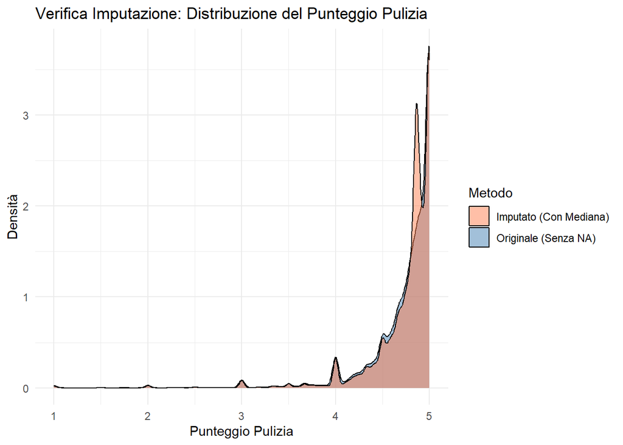

```r
# Grafico di densità per confrontare la distribuzione
ggplot() +
  # Curva dei dati originali (prendiamo df_pulito dove ci sono gli NA originali)
  geom_density(data = df_pulito %>% drop_na(review_scores_cleanliness),
               aes(x = review_scores_cleanliness #la stessa cosa vale                                             anche per review_scores_rating
                   , fill = "Originale (Senza NA)"),
               alpha = 0.5) +
  # Curva dei dati imputati
  geom_density(data = df_imputato_mediana,
               aes(x = review_scores_cleanliness, fill = "Imputato (Con Mediana)"),
               alpha = 0.5) +
  theme_minimal() +
  labs(title = "Verifica Imputazione: Distribuzione del Punteggio Pulizia",
       x = "Punteggio Pulizia", y = "Densità", fill = "Metodo") +
  scale_fill_manual(values = c("Originale (Senza NA)" = "steelblue", "Imputato (Con Mediana)" = "coral"))
```

### Validazione dell’Imputazione dei Valori Mancanti (Analisi di Densità)

Al fine di accertare che la procedura di imputazione dei *missing values* (effettuata tramite il calcolo della mediana) non introducesse distorsioni o *bias*, ho sovrapposto le curve di densità della variabile originale e di quella imputata. Come si evince dal grafico, la distribuzione *post-imputazione* preserva quasi perfettamente la struttura originale.

```r
# Calcolo Media e Deviazione Standard sui dati orginali (ignorando gli NA)
media_orig <- mean(df_pulito$review_scores_rating, na.rm = TRUE)
sd_orig <- sd(df_pulito$review_scores_rating, na.rm = TRUE)

# Calcolo Media e Deviazione Standard sui dati imputati
media_imp <- mean(df_final$review_scores_rating)
sd_imp <- sd(df_final$review_scores_rating)

# Confronto
cat("DATI ORIGINALI -> Media:", media_orig, " | Deviazione Standard:", sd_orig, "\n")
```

```
## DATI ORIGINALI -> Media: 4.710618  | Deviazione Standard: 0.4143158
```

```r
cat("DATI IMPUTATI  -> Media:", media_imp, " | Deviazione Standard:", sd_imp, "\n")
```

```
## DATI IMPUTATI  -> Media: 4.726976  | Deviazione Standard: 0.3791511
```

```r
# Seleziono 3 variabili numeriche chiave per il test
colonne_test <- c("review_scores_rating", "review_scores_cleanliness", "price")

# Correlazione originale (usando 'complete.obs' per scartare temporaneamente gli NA)
correlazione_originale <- cor(df_final %>% select(all_of(colonne_test)), use = "complete.obs")

# Correlazione sui dati imputati
correlazione_imputata <- cor(df_imputato_mediana %>% select(all_of(colonne_test)))

# CONFRONTO
print("--- MATRICE ORIGINALE ---")
```

```
## [1] "--- MATRICE ORIGINALE ---"
```

```r
print(round(correlazione_originale, 3))
```

```
##                           review_scores_rating review_scores_cleanliness  price
## review_scores_rating                     1.000                     0.786 -0.031
## review_scores_cleanliness                0.786                     1.000 -0.003
## price                                   -0.031                    -0.003  1.000
```

```r
print("--- MATRICE CON IMPUTAZIONE ---")
```

```
## [1] "--- MATRICE CON IMPUTAZIONE ---"
```

```r
print(round(correlazione_imputata, 3))
```

```
##                           review_scores_rating review_scores_cleanliness  price
## review_scores_rating                     1.000                     0.786 -0.031
## review_scores_cleanliness                0.786                     1.000 -0.003
## price                                   -0.031                    -0.003  1.000
```

### Esito del Test di Correlazione

Le due matrici dimostrano che l’imputazione con la mediana non ha alterato la struttura del dataset:

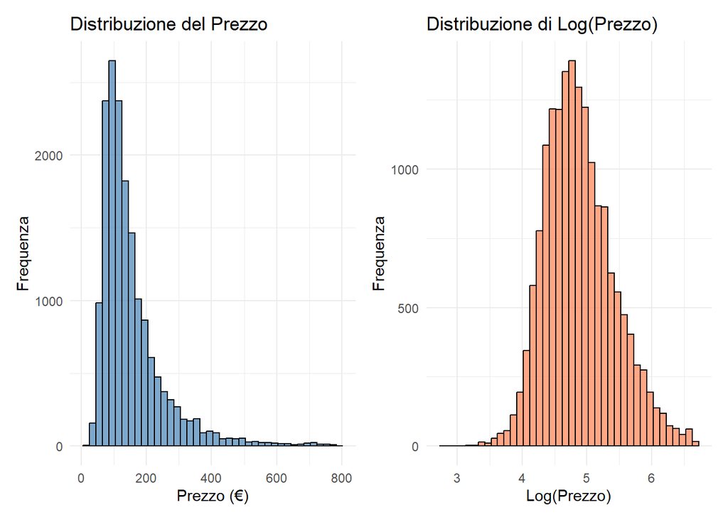

```r
# Aggiungo la var log_price al dataset per la regressione
df_final <- df_final %>%
  mutate(log_price = log(price))

# Grafico Prezzo normale
p1 <- ggplot(df_final, aes(x = price)) +
  geom_histogram(bins = 40, fill = "steelblue", color = "black", alpha = 0.7) +
  theme_minimal() +
  labs(title = "Distribuzione del Prezzo", x = "Prezzo (€)", y = "Frequenza")

# Grafico Log Prezzo
p2 <- ggplot(df_final, aes(x = log(price))) +
  geom_histogram(bins = 40, fill = "coral", color = "black", alpha = 0.7) +
  theme_minimal() +
  labs(title = "Distribuzione di Log(Prezzo)", x = "Log(Prezzo)", y = "Frequenza")

# Confronto
p1 + p2
```

- **Prezzo originale:** Mostra una tipica **asimmetria positiva**. La maggioranza degli alloggi a Milano si concentra nella fascia bassa (tra i 50€ e i 200€), creando un picco a sinistra. C’è però una lunga coda verso destra formata da un numero ristretto di alloggi di lusso (fino a 800€).
- **Log del Prezzo:** Applicando il logaritmo, la scala si comprime (soprattutto per i valori alti), la distribuzione asimmetrica si è trasformata in una **curva quasi normale.**

### Perché ho scelto di usare il Log?

1. **Assunzione OLS:** L’ OLS classico assume che i *residui* siano distribuiti normalmente. Usando una Y asimmetrica come quella di sinistra, i residui non saranno normali e il modello perderà validità statistica. Usando il logaritmo, si stabilizza la varianza (riducendo l’eteroschedasticità) garantendo stime più affidabili.
2. **Outlier:** Il logaritmo “schiaccia” i valori estremi della coda destra, riducendo il loro peso. In questo modo, le case da 800€ non tireranno più la retta di regressione verso di sé.
3. **Interpretazione Economica:** Utilizzando un mod log-lineare ci permette di leggere i coefficienti in termini di aumento percentuale, nel mercato immobiliare ragionare in percentuali è molto più realistico rispetto a ragionare in valori assoluti.

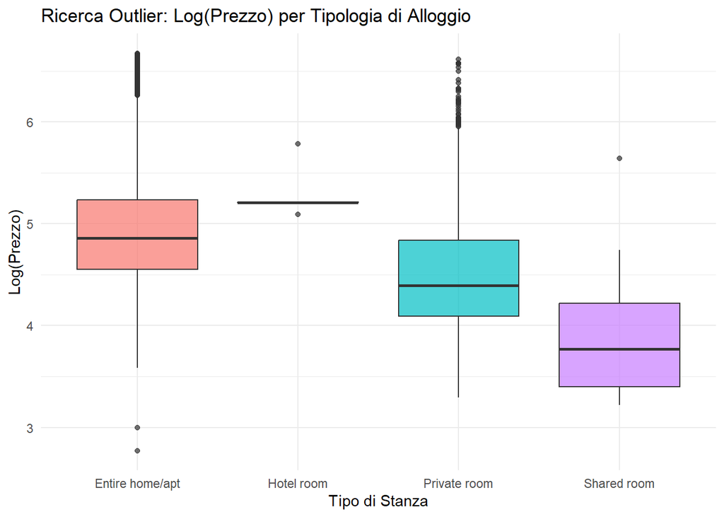

```r
# Boxplot per individuare outlier nei prezzi in base al tipo di stanza
ggplot(df_final, aes(x = room_type, y = log(price), fill = room_type)) +
  geom_boxplot(alpha = 0.7) +
  theme_minimal() +
  labs(title = "Ricerca Outlier: Log(Prezzo) per Tipologia di Alloggio",
       x = "Tipo di Stanza", y = "Log(Prezzo)") +
  theme(legend.position = "none")
```

- **La Gerarchia dei Prezzi:** Il boxplot mostra una chiara e logica gerarchia nei prezzi mediani. Come atteso dalle logiche di mercato, l’utilità marginale per il consumatore diminuisce al diminuire dello spazio e della privacy: un intero appartamento (`Entire home/apt`) ha una mediana nel prezzo superiore a una stanza privata (`Private room`), la quale a sua volta è più costosa di una stanza condivisa (`Shared room`).
- **L’Esclusione degli Hotel:** La categoria `Hotel room` presenta un boxplot ‘schiacciato’ in una singola linea orizzontale, sintomo di una varianza quasi nulla dovuta a un numero di osservazioni irrilevante. Dal punto di vista del dominio, Airbnb è una piattaforma *peer-to-peer*; l’inclusione di strutture alberghiere prevede logiche diverse. Per mantenere la coerenza del mercato analizzato ed evitare distorsioni nei coefficienti di regressione, si è deciso di rimuovere questa categoria dal dt.
- **Outlier di Lusso:** Nonostante la trasformazione logaritmica abbia compresso la scala, le categorie `Entire home/apt` e `Private room` mostrano una moltitudine di outlier superiori, questi non sono necessariamente errori di digitazione, ma mostrano l’esistenza di un segmento ‘Luxury’ che si discosta dai prezzi standard di Milano.

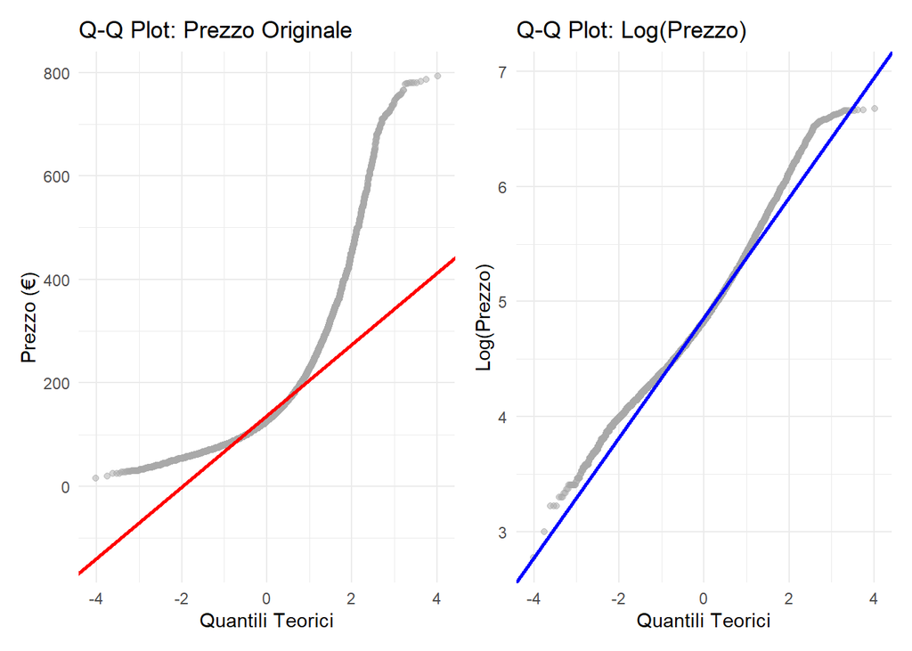

```r
# Q-Q Plot Prezzo Originale
qq_originale <- ggplot(df_final, aes(sample = price)) +
  stat_qq(color = "darkgray", alpha = 0.5) +
  stat_qq_line(color = "red", linewidth = 1) +
  theme_minimal() +
  labs(title = "Q-Q Plot: Prezzo Originale",
       x = "Quantili Teorici", y = "Prezzo (€)")

# Q-Q Plot Log Prezzo
qq_log <- ggplot(df_final, aes(sample = log_price)) +
  stat_qq(color = "darkgray", alpha = 0.5) +
  stat_qq_line(color = "blue", linewidth = 1) +
  theme_minimal() +
  labs(title = "Q-Q Plot: Log(Prezzo)",
       x = "Quantili Teorici", y = "Log(Prezzo)")

qq_originale + qq_log
```

Il Q-Q plot del prezzo originale evidenzia un marcato scostamento dalla retta di normalità nella parte superiore, confermando la presenza di una pesante coda destra (valori estremi). L’applicazione del log linearizza significativamente la distribuzione, stabilizzando la varianza e rendendo la variabile target idonea per le assunzioni della regressione OLS.

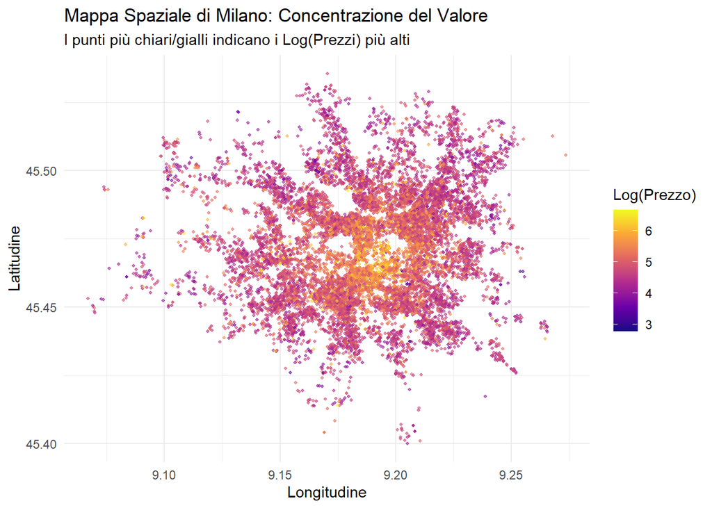

```r
# Mappa spaziale degli alloggi colorata per Log(Prezzo)
ggplot(df_final, aes(x = longitude, y = latitude, color = log_price)) +
  geom_point(alpha = 0.6, size = 0.8) +

  scale_color_viridis_c(option = "plasma") +
  theme_minimal() +
  labs(title = "Mappa Spaziale di Milano: Concentrazione del Valore",
       subtitle = "I punti più chiari/gialli indicano i Log(Prezzi) più alti",
       x = "Longitudine", y = "Latitudine", color = "Log(Prezzo)") +
  theme(legend.position = "right")
```

### Analisi Spaziale

**Evidenza del Modello Monocentrico:** Il grafico a dispersione restituisce la sagoma urbana di Milano, evidenziando una struttura economica fortemente monocentrica. Si osserva un nucleo centrale di estrema concentrazione del valore (i punti color giallo, corrispondenti ai valori massimi di `log_price` prossimi a 6), che rappresenta esattamente il centro città (Duomo, San Babila, Brera e Quadrilatero della Moda). In questa zona, l’inelasticità dell’offerta spaziale e l’altissima domanda generano un fortissimo aumento del prezzo.

**Il Gradiente Centro-Periferia:** Allontanandosi dal nucleo centrale, si nota una evidente discesa del prezzo. Questa transizione cromatica conferma che la propensione a pagare dei consumatori diminuisce proporzionalmente all’aumentare della distanza dai principali poli di attrazione.

**Implicazioni per la Modellazione:** Dal punto di vista statistico, questa mappa è la prova dell’esistenza di una forte **autocorrelazione spaziale** dei prezzi. Dimostra che il valore di un alloggio su Airbnb non è dettato solo dalle sue caratteristiche strutturali (camere, posti letto), ma dipende fortemnete dalla sua posizione. Questa evidenza giustifica e rende necessario l’inclusione delle variabili geografiche (come `neighbourhood_cleansed` o le stesse coordinate spaziali) come predittori fondamentali all’interno del modello OLS, al fine di evitare il problema della variabile omessa.

```r
# Conteggio di tutte le tipologie
df_final %>%
  count(room_type, name = "Numero_Alloggi") %>%
  mutate(Percentuale = round((Numero_Alloggi / sum(Numero_Alloggi)) * 100, 2))
```

```
## # A tibble: 4 × 3
##   room_type       Numero_Alloggi Percentuale
##   <chr>                    <int>       <dbl>
## 1 Entire home/apt          15532       91.3
## 2 Hotel room                   6        0.04
## 3 Private room              1440        8.46
## 4 Shared room                 42        0.25
```

```r
# Elimino le hotel room
df_final <- df_final %>%
  filter(room_type != "Hotel room")

# Controllo
table(df_final$room_type)
```

```
##
## Entire home/apt    Private room     Shared room
##           15532            1440              42
```

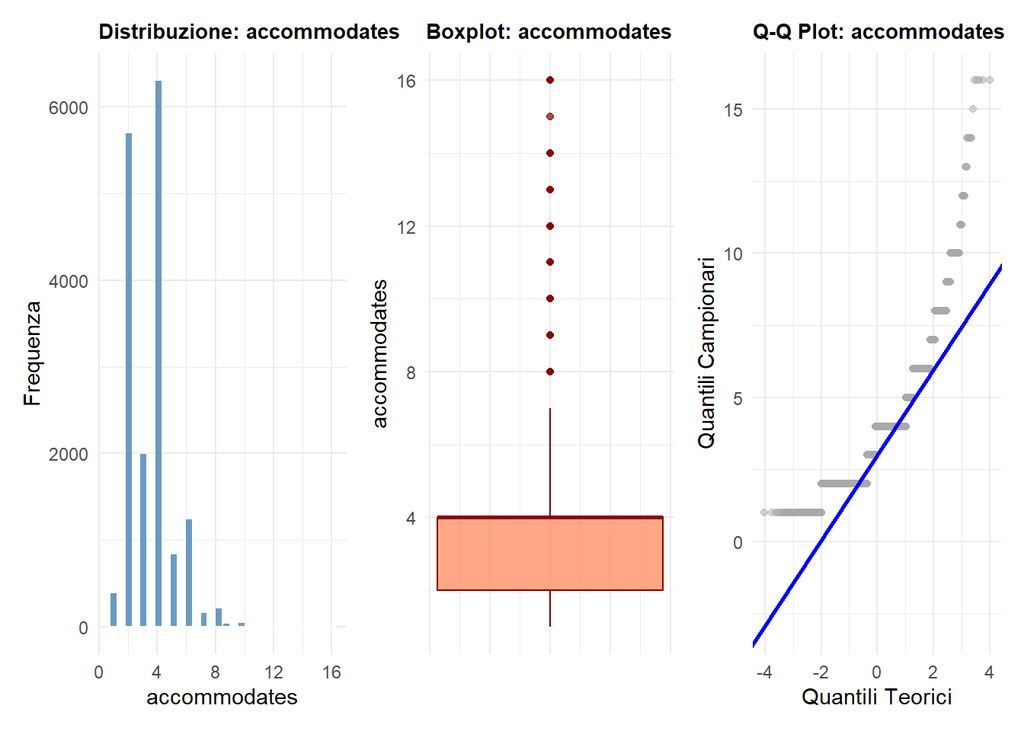

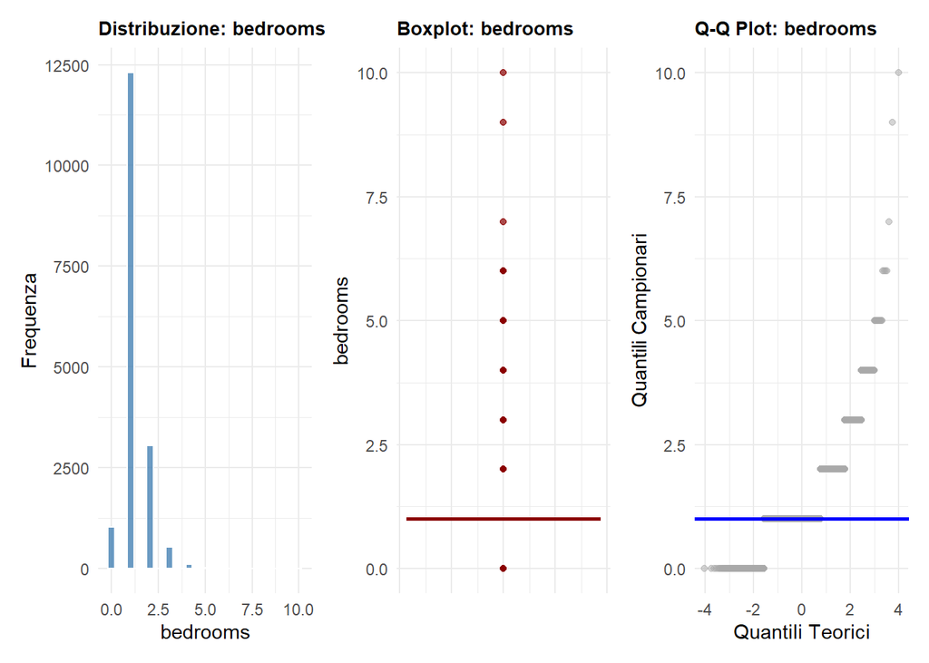

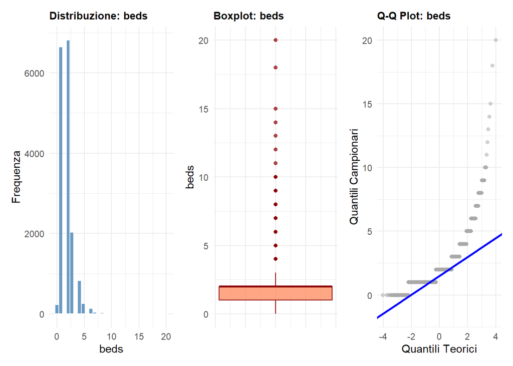

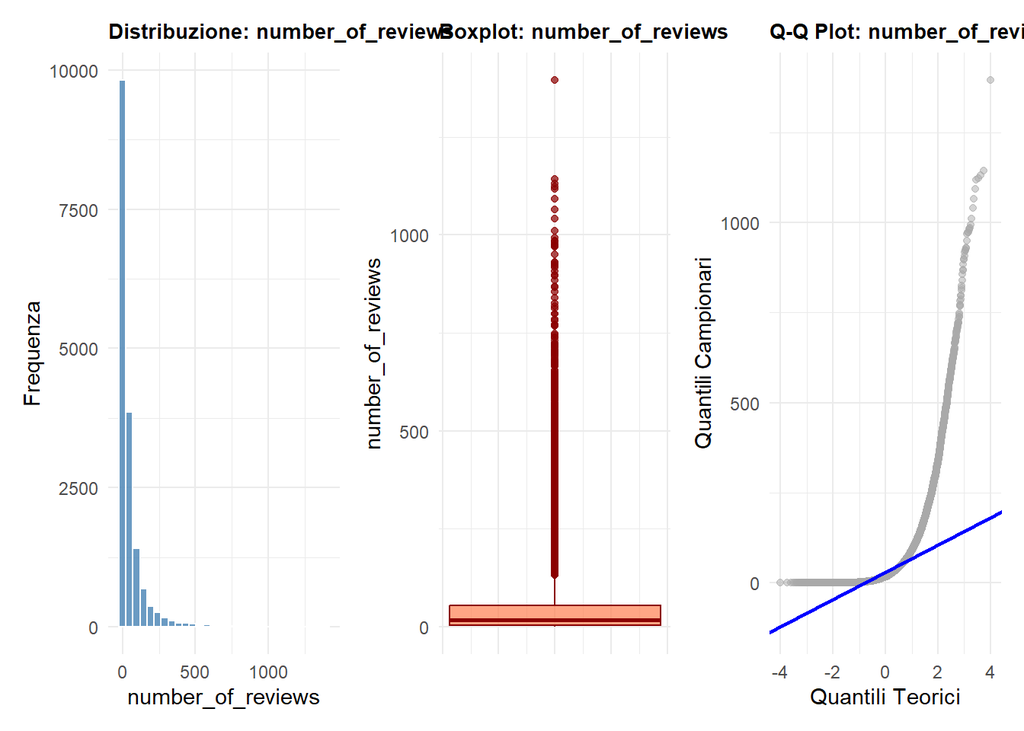

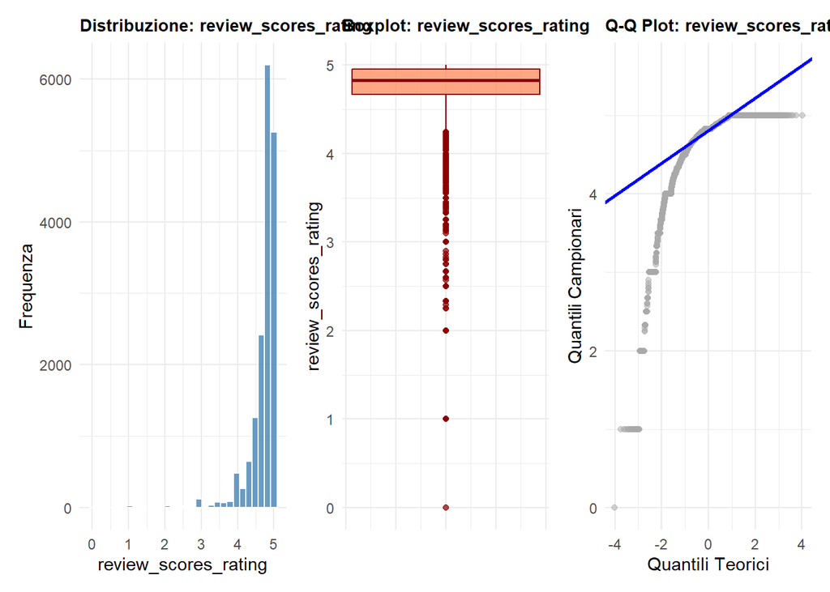

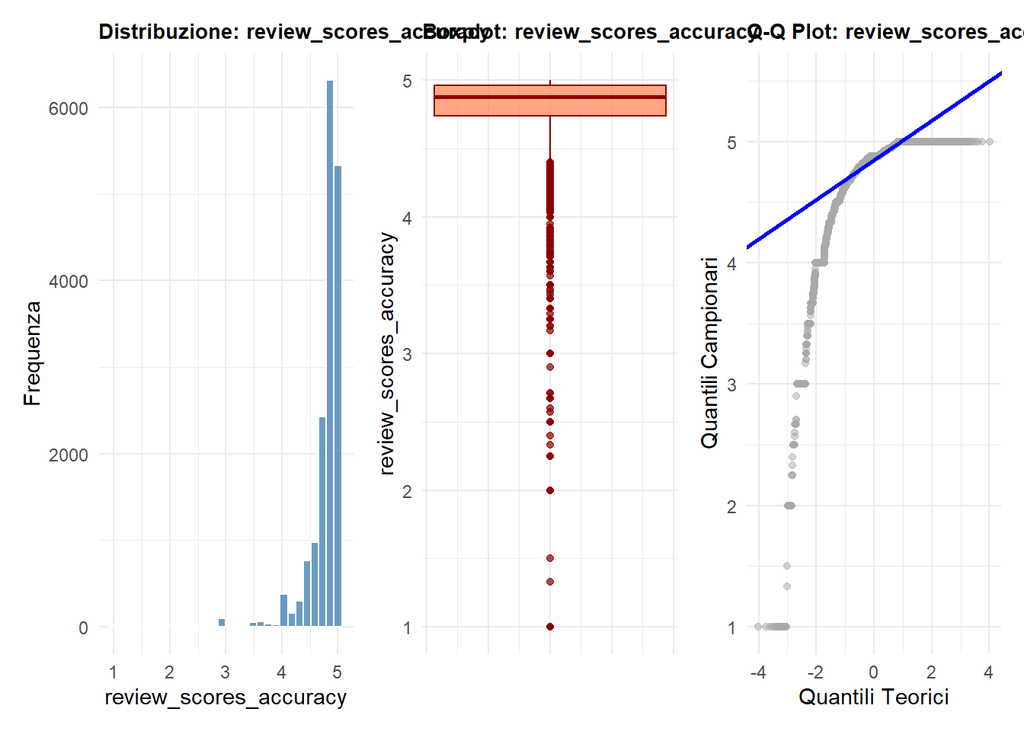

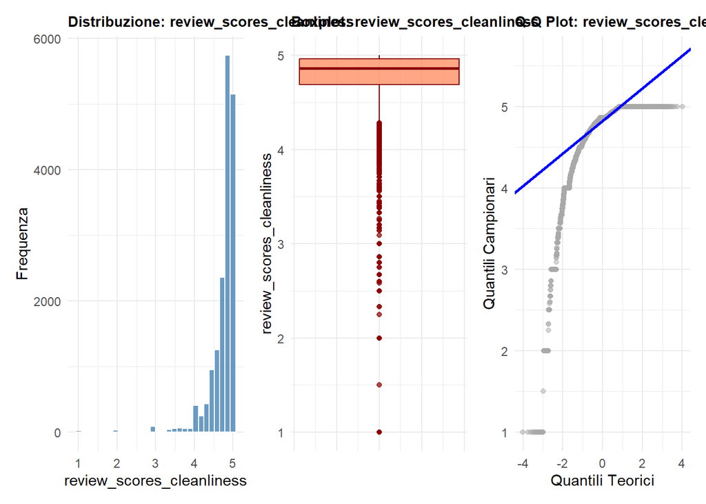

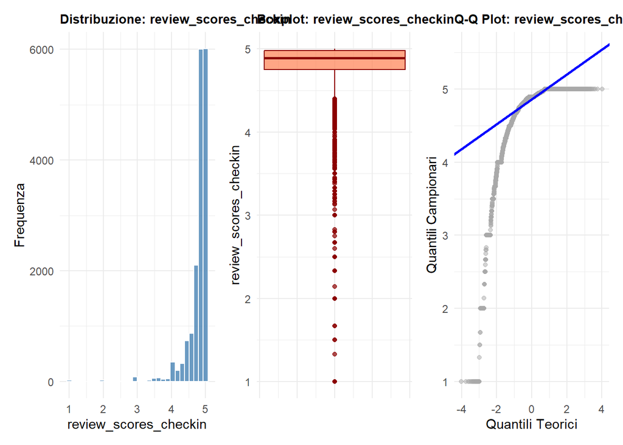

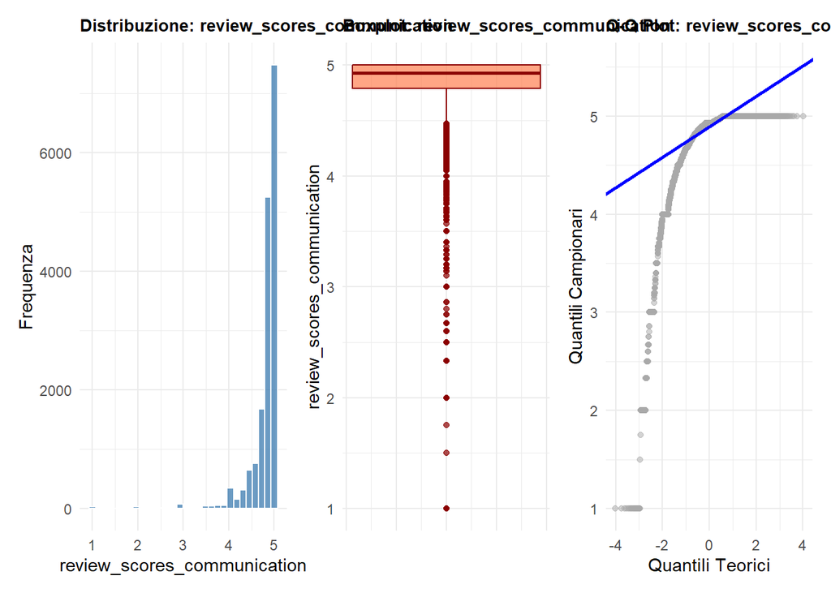

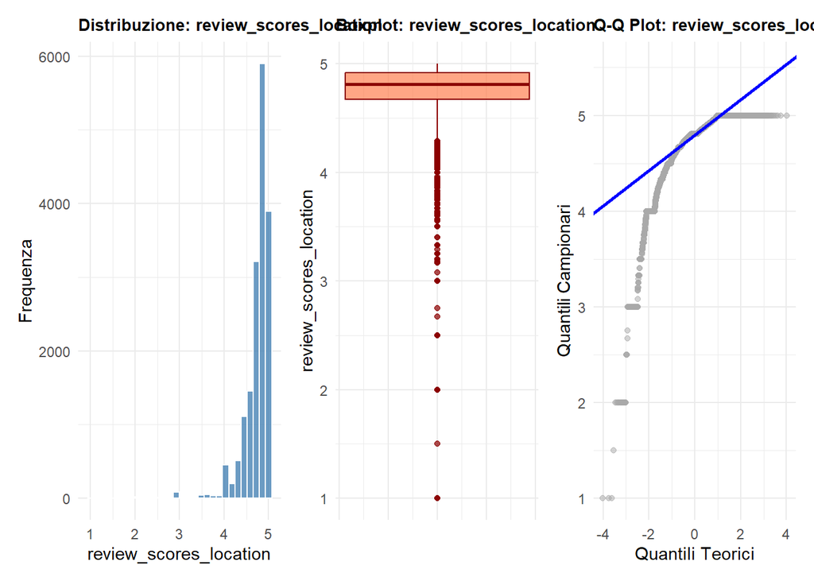

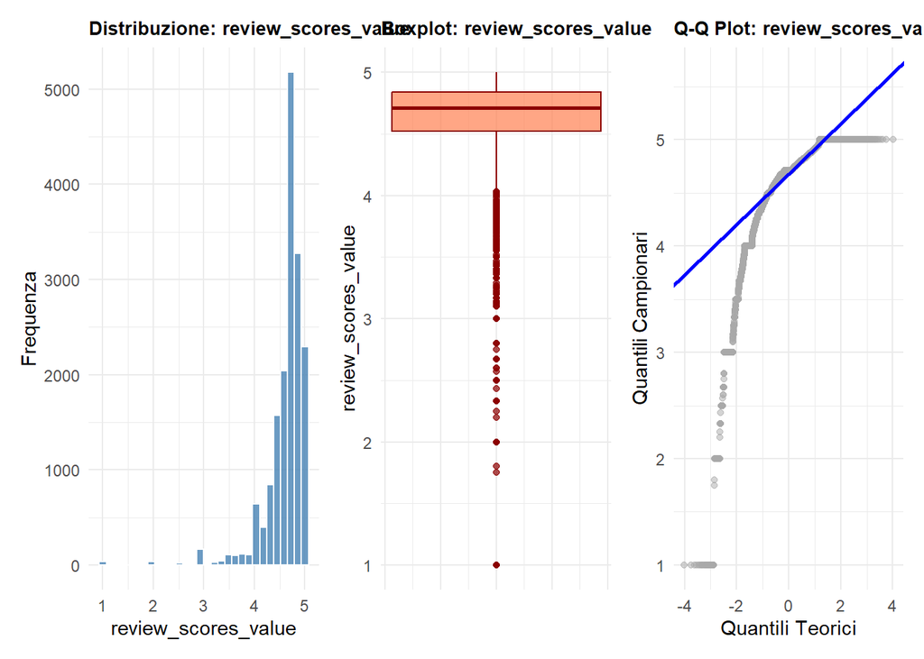

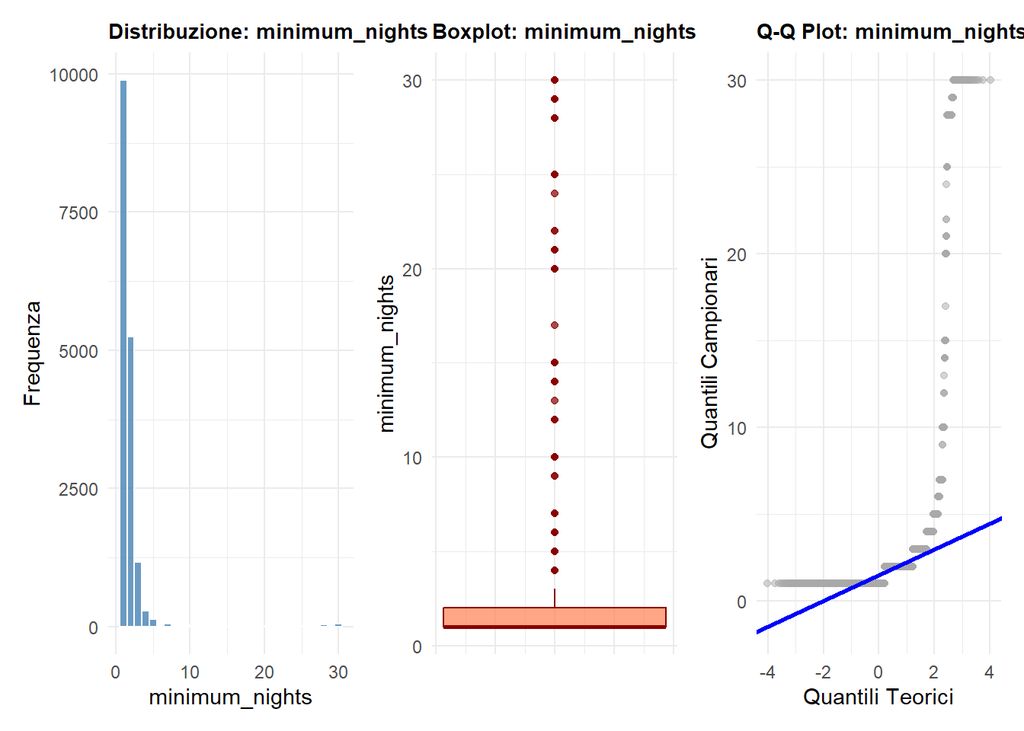

[2 more figures not shown]

```r
# Identifico le colonne numeriche
var_numeriche <- df_final %>%
  select(where(is.numeric)) %>%
  names()

# Escludo latitudine, longitudine e i prezzi (già analizzati a parte)
var_numeriche <- setdiff(var_numeriche, c("latitude", "longitude", "price", "log_price"))

# Creo un ciclo che passa su ogni variabile numerica rimasta
for (var in var_numeriche) {

  # A. Istogramma
  p_hist <- ggplot(df_final, aes(x = .data[[var]])) +
    geom_histogram(bins = 30, fill = "steelblue", color = "white", alpha = 0.8) +
    theme_minimal() +
    labs(title = paste("Distribuzione:", var), x = var, y = "Frequenza") +
    theme(plot.title = element_text(size = 10, face = "bold"))

  # B. Boxplot
  p_box <- ggplot(df_final, aes(y = .data[[var]])) +
    geom_boxplot(fill = "coral", color = "darkred", alpha = 0.7) +
    theme_minimal() +
    labs(title = paste("Boxplot:", var), y = var, x = "") +
    theme(axis.text.x = element_blank(), axis.ticks.x = element_blank(),
          plot.title = element_text(size = 10, face = "bold"))

  # C. Q-Q Plot
  p_qq <- ggplot(df_final, aes(sample = .data[[var]])) +
    stat_qq(color = "darkgray", alpha = 0.5) +
    stat_qq_line(color = "blue", linewidth = 1) +
    theme_minimal() +
    labs(title = paste("Q-Q Plot:", var), x = "Quantili Teorici", y = "Quantili Campionari") +
    theme(plot.title = element_text(size = 10, face = "bold"))

  # Uniamo i 3 grafici in un'unica riga e li stampiamo
  grafico_combinato <- p_hist + p_box + p_qq + plot_layout(ncol = 3)
  print(grafico_combinato)
}
```

### Scelte Metodologiche sulle Trasformazioni delle Variabili Indipendenti

Dopo aver analizzato la distrivuzione dei regressori ho deciso di mantenere la maggior parte dei regressori nella loro scala lineare originale, trasformando in log esclusivamente la var number_of_review.

Questa scelta è supportata da tre motivazioni statistiche ed economiche:

1. **Asimmetria Estrema e Rendimenti Marginali Decrescenti:** L’unica variabile esplicativa a presentare una grande asimmetria positiva è il numero di recensioni. Le statistiche mostrano una media aritmetica 51.18 pari a quasi il triplo della mediana 17, con un valore massimo anomalo di 1395 recensioni. Lasciare questa variabile in forma lineare avrebbe distorto la stima dei coefficienti, attribuendo un peso eccessivo agli outlier. Inoltre, dal punto di vista del comportamento del consumatore, l’impatto delle recensioni segue la legge dei rendimenti marginali decrescenti: la differenza di attrattività tra avere 0 o 10 recensioni è cruciale, mentre la differenza tra averne 500 o 510 è trascurabile. La trasformazione logaritmica (nella forma log(x+1) per gestire gli zeri) modella questa dinamica economica non lineare.
2. **Simmetria delle Variabili Continue:** Variabili strutturali continue, come la distanza dal centro (`distanza_centro_km`), non necessitano di trasformazioni in quanto presentano una distribuzione abbastanza simmetrica. Per questa specifica variabile, la media 2.92 km e la mediana (2.74 km) risultano quasi coincidenti. L’applicazione di un logaritmo a una variabile già bilanciata ne avrebbe distorto inutilmente la distribuzione, compromettendo inoltre la semplice interpretazione economica del coefficiente (il deprezzamento per ogni chilometro aggiuntivo).
3. **Interpretabilità delle Variabili di Conteggio:** Regressori discreti come il numero `bedrooms` e di `bathrooms` presentano un *range* di variazione estremamente ristretto (il 75% delle osservazioni si concentra sul valore 1) e contengono valori minimi pari a zero (ad es monolocali). Poiché il logaritmo di zero è indefinito, la trasformazione in log sarebbe stata priva di utilità pratica. Inoltre, mantenere queste variabili in scala lineare garantisce un’interpretabilità diretta dei coefficienti (il prezzo “aggiuntivo” per una stanza o un bagno in più).

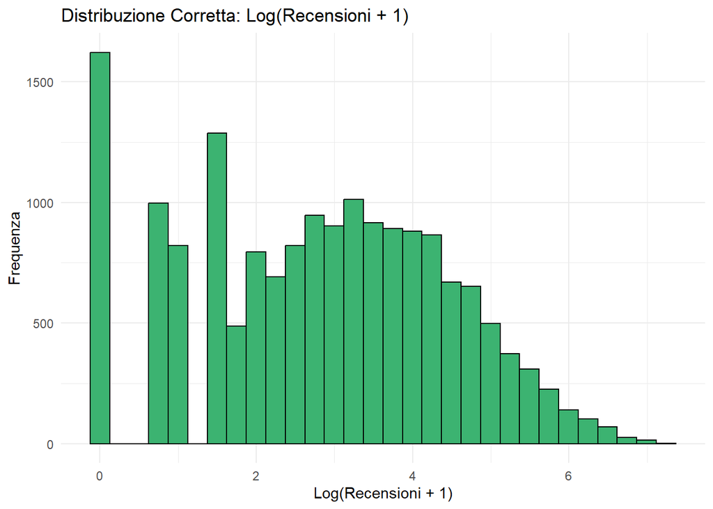

```r
library(dplyr)

# Creo la variabile log recensioni log(x + 1)
df_final <- df_final %>%
  mutate(log_reviews = log(number_of_reviews + 1))

# Grafico
ggplot(df_final, aes(x = log_reviews)) +
  geom_histogram(bins = 30, fill = "mediumseagreen", color = "black") +
  theme_minimal() +
  labs(title = "Distribuzione Corretta: Log(Recensioni + 1)", x = "Log(Recensioni + 1)", y = "Frequenza")
```

```r
# Selezino solo le variabili numeriche rilevanti
df_corr <- df_final %>%
  select(where(is.numeric)) %>%
  # Escludo le coordinate geografiche e le versioni non-logaritmiche di prezzo e recensioni
  select(-c(latitude, longitude, price, number_of_reviews))

# Matrice di correlazione
matrice_correlazione <- cor(df_corr, use = "complete.obs")

# Mostro matrice (arrotondata a 2 decimali per leggibilità)
cat("--- MATRICE DI CORRELAZIONE NUMERICA ---\n")
```

```
## --- MATRICE DI CORRELAZIONE NUMERICA ---
```

```r
print(round(matrice_correlazione, 2))
```

```
##                             accommodates bedrooms  beds review_scores_rating
## accommodates                        1.00     0.66  0.75                -0.02
## bedrooms                            0.66     1.00  0.63                 0.01
## beds                                0.75     0.63  1.00                -0.02
## review_scores_rating               -0.02     0.01 -0.02                 1.00
## review_scores_accuracy             -0.04    -0.01 -0.03                 0.84
## review_scores_cleanliness          -0.04    -0.01 -0.03                 0.79
## review_scores_checkin              -0.04     0.00 -0.02                 0.72
## review_scores_communication        -0.02     0.01 -0.01                 0.77
## review_scores_location             -0.01     0.00 -0.01                 0.53
## review_scores_value                 0.00     0.02  0.00                 0.85
## minimum_nights                     -0.06     0.01  0.00                 0.05
## availability_365                    0.03     0.01  0.03                -0.02
## bathrooms                           0.46     0.59  0.45                 0.00
## log_price                           0.40     0.36  0.29                -0.05
## log_reviews                         0.00     0.03  0.05                 0.12
##                             review_scores_accuracy review_scores_cleanliness
## accommodates                                 -0.04                     -0.04
## bedrooms                                     -0.01                     -0.01
## beds                                         -0.03                     -0.03
## review_scores_rating                          0.84                      0.79
## review_scores_accuracy                        1.00                      0.73
## review_scores_cleanliness                     0.73                      1.00
## review_scores_checkin                         0.65                      0.57
## review_scores_communication                   0.70                      0.61
## review_scores_location                        0.51                      0.46
## review_scores_value                           0.80                      0.74
## minimum_nights                                0.04                      0.02
## availability_365                             -0.03                     -0.03
## bathrooms                                    -0.01                     -0.01
## log_price                                    -0.05                     -0.01
## log_reviews                                   0.11                      0.08
##                             review_scores_checkin review_scores_communication
## accommodates                                -0.04                       -0.02
## bedrooms                                     0.00                        0.01
## beds                                        -0.02                       -0.01
## review_scores_rating                         0.72                        0.77
## review_scores_accuracy                       0.65                        0.70
## review_scores_cleanliness                    0.57                        0.61
## review_scores_checkin                        1.00                        0.74
```

[output cut: 41 more lines]

```
## accommodates                       0.00
## bedrooms                           0.03
## beds                               0.05
## review_scores_rating               0.12
## review_scores_accuracy             0.11
## review_scores_cleanliness          0.08
## review_scores_checkin              0.10
## review_scores_communication        0.12
## review_scores_location             0.07
## review_scores_value                0.15
## minimum_nights                    -0.04
## availability_365                  -0.06
## bathrooms                          0.02
## log_price                         -0.17
## log_reviews                        1.00
```

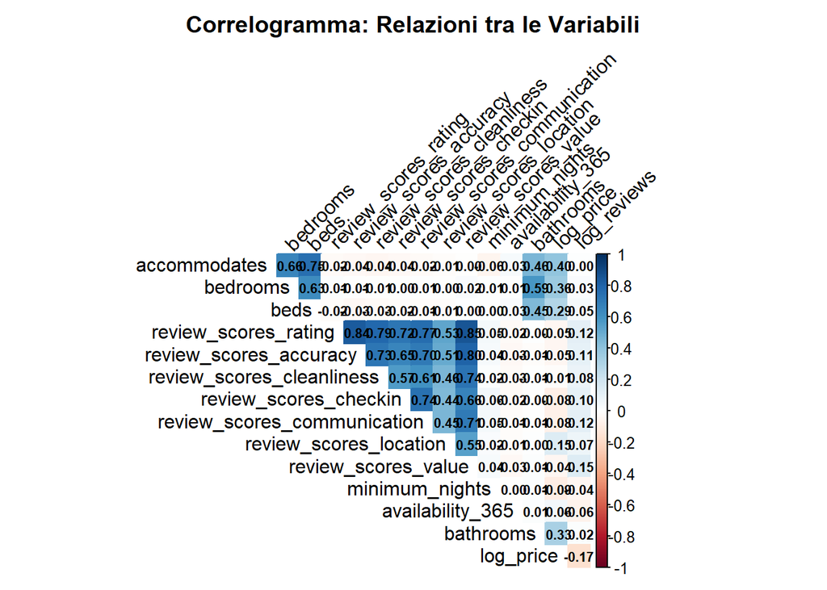

```r
# Correlogramma
corrplot(matrice_correlazione,
         method = "color",       # Usa i colori per indicare l'intensità
         type = "upper",         # Mostra solo il triangolo superiore (è simmetrica)
         tl.col = "black",       # Colore del testo delle etichette
         tl.srt = 45,            # Inclinazione delle etichette a 45 gradi
         addCoef.col = "black",  # Stampa i numerini dentro i quadrati
         number.cex = 0.7,       # Dimensione dei numerini
         diag = FALSE,           # Nasconde la diagonale (che è sempre 1)
         title = "Correlogramma: Relazioni tra le Variabili",
         mar = c(0,0,2,0))       # Margini per far spazio al titolo
```

### L’Indice di “Capacità Strutturale”

Potrebbero essere messe tutte e 3 in una PCA e creare una singola var chimata indice_capacita.

### La Qualità Percepita (Le Recensioni)

Si potrebbe fare una PCA su tutto il blocco recensioni per estrarre un singolo **`indice_qualita`**.

```r
# MODELLO OLS BASE
modello_base <- lm(log_price ~ room_type + accommodates + bedrooms + bathrooms +
                   host_is_superhost + review_scores_rating + log_reviews +
                   minimum_nights + availability_365 + neighbourhood_cleansed,
                   data = df_final)

summary(modello_base)
```

```
##
## Call:
## lm(formula = log_price ~ room_type + accommodates + bedrooms +
##     bathrooms + host_is_superhost + review_scores_rating + log_reviews +
##     minimum_nights + availability_365 + neighbourhood_cleansed,
##     data = df_final)
##
## Residuals:
##     Min      1Q  Median      3Q     Max
## -3.1883 -0.2451 -0.0293  0.2174  2.1900
##
## Coefficients:
##                                                      Estimate Std. Error
## (Intercept)                                         4.153e+00  6.512e-02
## room_typePrivate room                              -2.023e-01  1.135e-02
## room_typeShared room                               -8.649e-01  5.974e-02
## accommodates                                        6.311e-02  2.743e-03
## bedrooms                                            1.328e-01  6.915e-03
## bathrooms                                           1.438e-01  8.379e-03
## host_is_superhostTRUE                              -3.797e-03  6.797e-03
## review_scores_rating                                2.854e-02  8.114e-03
## log_reviews                                        -7.061e-02  1.959e-03
## minimum_nights                                     -1.765e-02  1.147e-03
## availability_365                                    1.393e-04  2.734e-05
## neighbourhood_cleansedAFFORI                       -7.612e-02  6.003e-02
## neighbourhood_cleansedBAGGIO                       -2.041e-01  7.771e-02
## neighbourhood_cleansedBANDE NERE                    8.387e-02  5.658e-02
## neighbourhood_cleansedBARONA                       -9.019e-02  8.252e-02
## neighbourhood_cleansedBICOCCA                      -3.418e-02  7.123e-02
## neighbourhood_cleansedBOVISA                       -5.349e-02  6.189e-02
## neighbourhood_cleansedBOVISASCA                     2.887e-02  1.378e-01
## neighbourhood_cleansedBRERA                         7.435e-01  5.400e-02
## neighbourhood_cleansedBRUZZANO                     -6.600e-02  8.538e-02
## neighbourhood_cleansedBUENOS AIRES - VENEZIA        3.855e-01  5.304e-02
## neighbourhood_cleansedCANTALUPA                     3.281e-01  1.983e-01
## neighbourhood_cleansedCENTRALE                      3.914e-01  5.376e-02
## neighbourhood_cleansedCHIARAVALLE                  -4.972e-01  3.861e-01
## neighbourhood_cleansedCITTA' STUDI                  1.119e-01  5.606e-02
## neighbourhood_cleansedCOMASINA                     -3.470e-02  9.533e-02
## neighbourhood_cleansedCORSICA                       1.426e-01  5.986e-02
```

[output cut: 157 more lines]

```
## neighbourhood_cleansedTRE TORRI                      2.575 0.010045 *
## neighbourhood_cleansedTRENNO                         0.044 0.964629
## neighbourhood_cleansedTRIULZO SUPERIORE             -1.274 0.202585
## neighbourhood_cleansedUMBRIA - MOLISE                0.525 0.599470
## neighbourhood_cleansedVIALE MONZA                   -1.220 0.222507
## neighbourhood_cleansedVIGENTINA                      6.398 1.62e-10 ***
## neighbourhood_cleansedVILLAPIZZONE                  -0.382 0.702373
## neighbourhood_cleansedWASHINGTON                     4.458 8.31e-06 ***
## neighbourhood_cleansedXXII MARZO                     6.030 1.67e-09 ***
## ---
## Signif. codes:  0 '***' 0.001 '**' 0.01 '*' 0.05 '.' 0.1 ' ' 1
##
## Residual standard error: 0.3826 on 16918 degrees of freedom
## Multiple R-squared:  0.4853, Adjusted R-squared:  0.4824
## F-statistic: 167.9 on 95 and 16918 DF,  p-value: < 2.2e-16
```

Per risolvere questo problema, basandomi sulla teoria dell’Economia Urbana. Seguendo il modello della ‘Città Monocentrica’, ho assunto il Duomo come centro, attraverso le coordinate geografiche, i quartieri sono stati sostituiti con una singola variabile continua (`distanza_centro_km`).

Questa trasformazione porta tre grandi vantaggi:

1. Riduce la complessità del modello, prevenendo l’overfitting e migliorando la leggibilità dell’output.
2. Cattura in modo molto più pulito l’autocorrelazione spaziale rilevata in fase di esplorazione visiva.
3. Permette di quantificare un ‘gradiente spaziale’. Invece di confrontare due quartieri, il coefficiente ci permette di rispondere a una domanda economica precisa: *Di quale percentuale diminuisce il prezzo dell’affitto per ogni chilometro di allontanamento dal centro?*.

```r
# Coordinate esatte di Piazza del Duomo
lat_duomo <- 45.4642
lon_duomo <- 9.1900

# Calcolo la distanza in metri e la convertiamo in chilometri
df_final <- df_final %>%
  mutate(
    distanza_centro_km = distHaversine(
      cbind(longitude, latitude), # Punto A: L'appartamento
      cbind(lon_duomo, lat_duomo) # Punto B: Il Duomo
    ) / 1000 # Dividiamo per 1000 per avere i Km
  )

# Controllo
summary(df_final$distanza_centro_km)
```

```
##     Min.  1st Qu.   Median     Mean  3rd Qu.     Max.
## 0.001561 1.814594 2.748506 2.927331 3.758546 9.692544
```

```r
# NUOVO MODELLO DI REGRESSIONE (Con Distanza dal Centro)

modello_pulito <- lm(log_price ~ room_type + accommodates + bedrooms + bathrooms +
                     host_is_superhost + review_scores_rating + log_reviews +
                     minimum_nights + availability_365 + distanza_centro_km,
                     data = df_final)

summary(modello_pulito)
```

```
##
## Call:
## lm(formula = log_price ~ room_type + accommodates + bedrooms +
##     bathrooms + host_is_superhost + review_scores_rating + log_reviews +
##     minimum_nights + availability_365 + distanza_centro_km, data = df_final)
##
## Residuals:
##     Min      1Q  Median      3Q     Max
## -3.5657 -0.2658 -0.0359  0.2283  2.3038
##
## Coefficients:
##                         Estimate Std. Error t value Pr(>|t|)
## (Intercept)            4.868e+00  4.143e-02 117.492  < 2e-16 ***
## room_typePrivate room -1.893e-01  1.176e-02 -16.094  < 2e-16 ***
## room_typeShared room  -9.103e-01  6.214e-02 -14.649  < 2e-16 ***
## accommodates           6.760e-02  2.859e-03  23.640  < 2e-16 ***
## bedrooms               1.284e-01  7.199e-03  17.837  < 2e-16 ***
## bathrooms              1.523e-01  8.712e-03  17.476  < 2e-16 ***
## host_is_superhostTRUE -1.040e-02  7.085e-03  -1.468    0.142
## review_scores_rating   2.055e-02  8.451e-03   2.432    0.015 *
## log_reviews           -6.683e-02  2.034e-03 -32.864  < 2e-16 ***
## minimum_nights        -1.930e-02  1.194e-03 -16.160  < 2e-16 ***
## availability_365       1.526e-04  2.847e-05   5.362 8.33e-08 ***
## distanza_centro_km    -1.452e-01  2.003e-03 -72.499  < 2e-16 ***
## ---
## Signif. codes:  0 '***' 0.001 '**' 0.01 '*' 0.05 '.' 0.1 ' ' 1
##
## Residual standard error: 0.4005 on 17002 degrees of freedom
## Multiple R-squared:  0.4332, Adjusted R-squared:  0.4329
## F-statistic:  1182 on 11 and 17002 DF,  p-value: < 2.2e-16
```

L’R-quadro evidenzia che riusciamo a spiegare linearmente oltre il 43% del prezzo usando solo coordinate, letti e recensioni.

Molta della variabilità non spiegata probanilmente contiene fattori come:

- La qualità dell’arredamento.
- La bellezza delle fotografie dell’annuncio.
- La vista dal balcone.
- L’irrazionalità umana (host inesperti che mettono prezzi a caso o troppo alti).

### SIGNIFICATIVITA’ e COEFFICIENTI

Praticamente tutte le var sono statisticamnete significative, l’unica eccezione è super_host (ceteris paribus lo status di super_host on ha un effetto statisticamnete significativo sul prezzo)

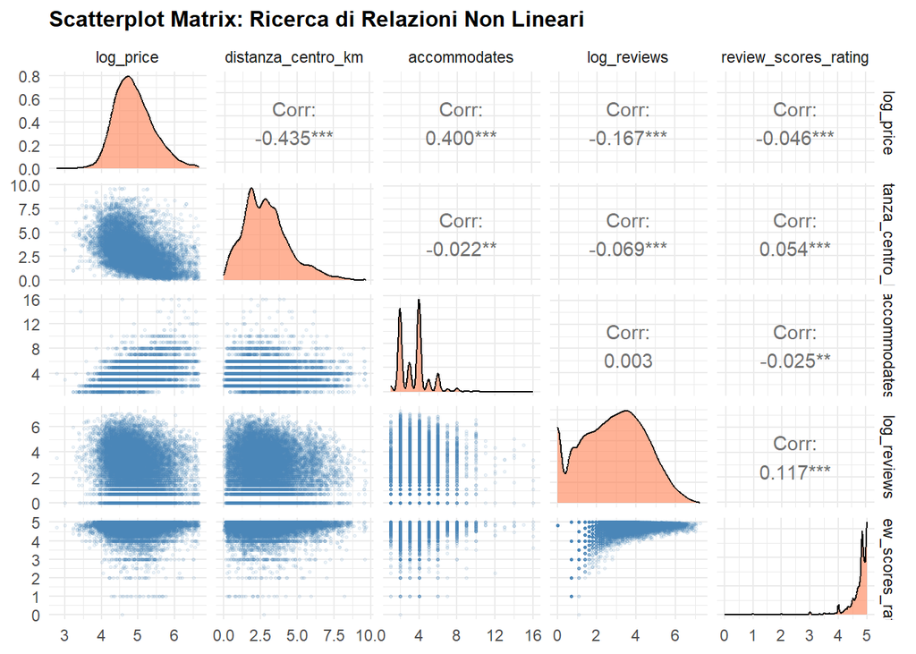

```r
# Selezioniamo solo le 5 variabili numeriche più importanti
df_scatter <- df_final %>%
  select(log_price, distanza_centro_km, accommodates, log_reviews, review_scores_rating)

# Matrice di Dispersione
ggpairs(df_scatter,
        # Impostiamo i punti in basso con una forte trasparenza (alpha = 0.1)
        # per vedere la densità reale dove i punti si sovrappongono
        lower = list(continuous = wrap("points", alpha = 0.1, size = 0.5, color = "steelblue")),
        # Sulla diagonale mettiamo le curve di densità
        diag = list(continuous = wrap("densityDiag", fill = "coral", alpha = 0.6)),
        title = "Scatterplot Matrix: Ricerca di Relazioni Non Lineari") +
  theme_minimal() +
  theme(plot.title = element_text(face = "bold", size = 12))
```

### Le Relazioni tra le Variabili

La matrice di dispersione permette in un unico grafico di osservare tre aspetti: come si distribuiscono i singoli dati (sulla diagonale principale), in che modo le caratteristiche dell’immobile influenzano il prezzo e, soprattutto, come interagiscono le variabili tra loro.

Dall’analisi della matrice emergono tre considerazioni:

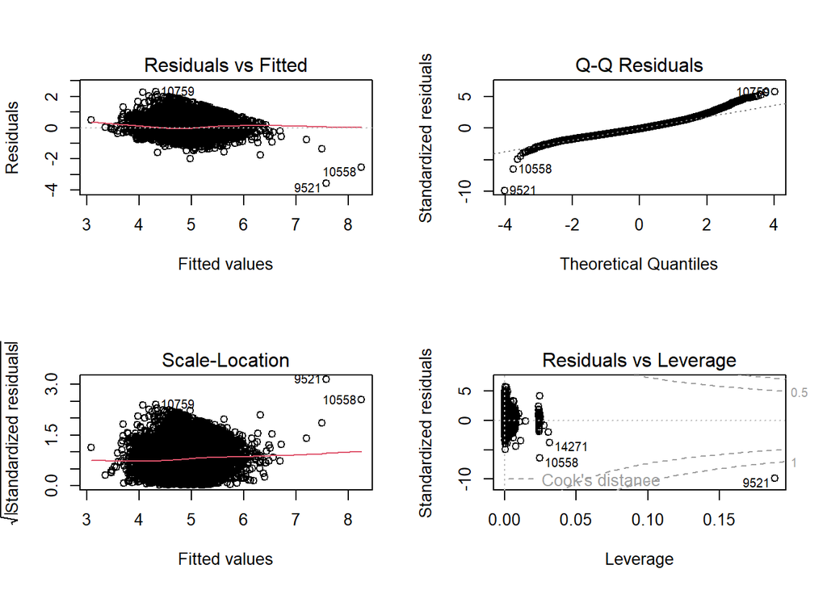

```r
par(mfrow = c(2, 2))

plot(modello_pulito)
```

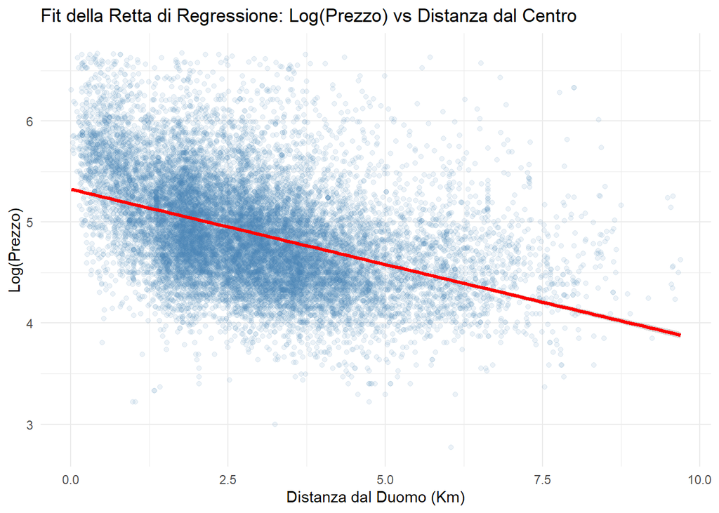

```r
par(mfrow = c(1, 1))

# Scatterplot con retta di regressione lineare
ggplot(df_final, aes(x = distanza_centro_km, y = log_price)) +
  # Usiamo alpha = 0.1 per gestire la sovrapposizione dei 17.000 punti
  geom_point(alpha = 0.1, color = "steelblue") +
  # Aggiungiamo la retta di regressione in rosso
  geom_smooth(method = "lm", color = "red", linewidth = 1.2) +
  theme_minimal() +
  labs(title = "Fit della Retta di Regressione: Log(Prezzo) vs Distanza dal Centro",
       x = "Distanza dal Duomo (Km)", y = "Log(Prezzo)")
```

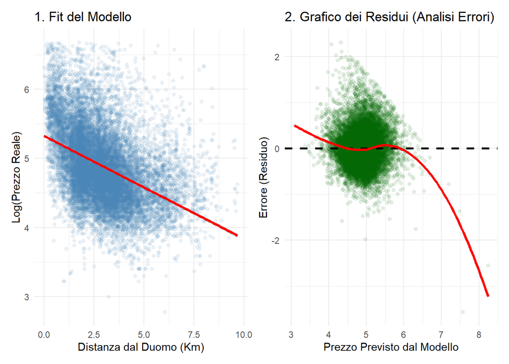

```r
# PLOT DELLA RETTA DI REGRESSIONE
plot_retta <- ggplot(df_final, aes(x = distanza_centro_km, y = log_price)) +
  geom_point(alpha = 0.1, color = "steelblue") +
  geom_smooth(method = "lm", color = "red", linewidth = 1.2) + # La retta dritta (lm)
  theme_minimal() +
  labs(title = "1. Fit del Modello",
       x = "Distanza dal Duomo (Km)", y = "Log(Prezzo Reale)")

#  PLOT DEI RESIDUI (Errori vs Valori Previsti)
df_residui <- data.frame(
  Fitted = fitted(modello_pulito),
  Residui = residuals(modello_pulito)
)

plot_residui <- ggplot(df_residui, aes(x = Fitted, y = Residui)) +
  geom_point(alpha = 0.1, color = "darkgreen") +
  # La retta di regressione "raddrizzata" (Errore = 0)
  geom_hline(yintercept = 0, linetype = "dashed", color = "black", linewidth = 1) +
  # La linea flessibile che cerca pattern negli errori
  geom_smooth(method = "loess", color = "red", se = FALSE, linewidth = 1.2) +
  theme_minimal() +
  labs(title = "2. Grafico dei Residui (Analisi Errori)",
       x = "Prezzo Previsto dal Modello", y = "Errore (Residuo)")

# Grafici affiancati
plot_retta + plot_residui
```

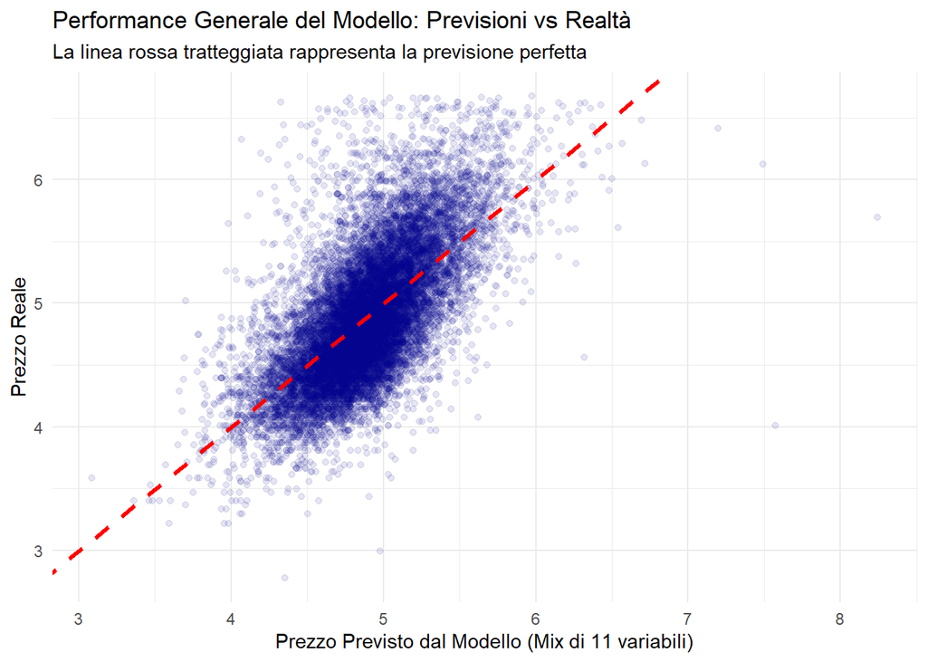

```r
df_previsioni <- data.frame(
  Reale = df_final$log_price,
  Previsto = fitted(modello_pulito)
)

# Grafico generale
ggplot(df_previsioni, aes(x = Previsto, y = Reale)) +
  geom_point(alpha = 0.1, color = "darkblue") +
  # Aggiungiamo la "Retta di Regressione Perfetta" (Diagonale a 45 gradi)
  geom_abline(intercept = 0, slope = 1, color = "red", linewidth = 1.2, linetype = "dashed") +
  theme_minimal() +
  labs(title = "Performance Generale del Modello: Previsioni vs Realtà",
       x = "Prezzo Previsto dal Modello (Mix di 11 variabili)",
       y = "Prezzo Reale",
       subtitle = "La linea rossa tratteggiata rappresenta la previsione perfetta")
```

```r
summary(df_final)
```

```
##      price     host_is_superhost     room_type      accommodates
##  Min.   : 16   Mode :logical     Length   :17014   Min.   : 1.000
##  1st Qu.: 91   FALSE:10911       N.unique :    3   1st Qu.: 2.000
##  Median :125   TRUE :6103        N.blank  :    0   Median : 4.000
##  Mean   :155                     Min.nchar:   11   Mean   : 3.463
##  3rd Qu.:184                     Max.nchar:   15   3rd Qu.: 4.000
##  Max.   :793                                       Max.   :16.000
##     bedrooms           beds        neighbourhood_cleansed    latitude
##  Min.   : 0.000   Min.   : 0.000   Length   :17014        Min.   :45.40
##  1st Qu.: 1.000   1st Qu.: 1.000   N.unique :   86        1st Qu.:45.46
##  Median : 1.000   Median : 2.000   N.blank  :    0        Median :45.47
##  Mean   : 1.204   Mean   : 1.906   Min.nchar:    4        Mean   :45.47
##  3rd Qu.: 1.000   3rd Qu.: 2.000   Max.nchar:   28        3rd Qu.:45.49
##  Max.   :10.000   Max.   :20.000                          Max.   :45.54
##    longitude     number_of_reviews review_scores_rating review_scores_accuracy
##  Min.   :9.067   Min.   :   0.00   Min.   :0.000        Min.   :1.000
##  1st Qu.:9.171   1st Qu.:   4.00   1st Qu.:4.670        1st Qu.:4.740
##  Median :9.188   Median :  17.00   Median :4.830        Median :4.880
##  Mean   :9.188   Mean   :  51.18   Mean   :4.727        Mean   :4.782
##  3rd Qu.:9.209   3rd Qu.:  55.00   3rd Qu.:4.950        3rd Qu.:4.960
##  Max.   :9.274   Max.   :1395.00   Max.   :5.000        Max.   :5.000
##  review_scores_cleanliness review_scores_checkin review_scores_communication
##  Min.   :1.000             Min.   :1.000         Min.   :1.000
##  1st Qu.:4.690             1st Qu.:4.750         1st Qu.:4.790
##  Median :4.860             Median :4.890         Median :4.930
##  Mean   :4.751             Mean   :4.785         Mean   :4.813
##  3rd Qu.:4.960             3rd Qu.:4.980         3rd Qu.:5.000
##  Max.   :5.000             Max.   :5.000         Max.   :5.000
##  review_scores_location review_scores_value minimum_nights   availability_365
##  Min.   :1.000          Min.   :1.000       Min.   : 1.000   Min.   :  0.0
##  1st Qu.:4.670          1st Qu.:4.520       1st Qu.: 1.000   1st Qu.:104.0
##  Median :4.810          Median :4.710       Median : 1.000   Median :201.0
##  Mean   :4.739          Mean   :4.617       Mean   : 1.811   Mean   :196.5
##  3rd Qu.:4.920          3rd Qu.:4.840       3rd Qu.: 2.000   3rd Qu.:294.8
##  Max.   :5.000          Max.   :5.000       Max.   :30.000   Max.   :365.0
##    bathrooms     has_reviews       log_price      log_reviews
##  Min.   : 0.00   Mode :logical   Min.   :2.773   Min.   :0.000
##  1st Qu.: 1.00   FALSE:1622      1st Qu.:4.511   1st Qu.:1.609
##  Median : 1.00   TRUE :15392     Median :4.828   Median :2.890
##  Mean   : 1.15                   Mean   :4.889   Mean   :2.797
##  3rd Qu.: 1.00                   3rd Qu.:5.215   3rd Qu.:4.025
##  Max.   :21.00                   Max.   :6.676   Max.   :7.241
##  distanza_centro_km
##  Min.   :0.001561
##  1st Qu.:1.814594
##  Median :2.748506
##  Mean   :2.927331
##  3rd Qu.:3.758546
##  Max.   :9.692544
```

### VIF E MULTICOLLINEARITÀ

```r
# TEST DI MULTICOLLINEARITÀ
cat("--- Risultati del VIF ---\n")
```

```
## --- Risultati del VIF ---
```

```r
vif(modello_pulito)
```

```
##                          GVIF Df GVIF^(1/(2*Df))
## room_type            1.145444  2        1.034531
## accommodates         2.017979  1        1.420556
## bedrooms             2.211432  1        1.487088
## bathrooms            1.569165  1        1.252663
## host_is_superhost    1.225209  1        1.106891
## review_scores_rating 1.089591  1        1.043835
## log_reviews          1.161671  1        1.077809
## minimum_nights       1.014274  1        1.007112
## availability_365     1.006427  1        1.003209
## distanza_centro_km   1.027244  1        1.013531
```

- Tutte le variabili geografiche, comportamentali e legate alle recensioni (come `distanza_centro_km`, `review_scores_rating` e `minimum_nights`) presentano un **VIF prossimo a 1**, indicando una quasi totale indipendenza lineare.
- I valori leggermente più alti si registrano, come atteso, nel blocco delle variabili legate alla capacità ricettiva: **bedrooms (2.21)**, **accommodates (2.01)** e **bathrooms (1.56)**.
- Questa lieve correlazione interna è giustificabile dal punto di vista architettonico e immobiliare (all’aumentare delle camere, aumentano di conseguenza i posti letto e i bagni). Tuttavia, trattandosi di valori al di sotto della soglia critica di 5, confermano che ciascuna di queste variabili apporta un contributo informativo unico e indipendente alla spiegazione del prezzo.

```r
# Modello con interazioni
modello_interazioni <- lm(log_price ~ accommodates + bedrooms + bathrooms +
                          host_is_superhost + review_scores_rating + log_reviews +
                          minimum_nights + availability_365 +
                          distanza_centro_km * room_type + # Effetto distanza che varia per tipo stanza
                          bathrooms:accommodates,          # Interazione tra bagni e posti letto
                          data = df_final)

summary(modello_interazioni)
```

```
##
## Call:
## lm(formula = log_price ~ accommodates + bedrooms + bathrooms +
##     host_is_superhost + review_scores_rating + log_reviews +
##     minimum_nights + availability_365 + distanza_centro_km *
##     room_type + bathrooms:accommodates, data = df_final)
##
## Residuals:
##     Min      1Q  Median      3Q     Max
## -3.8742 -0.2653 -0.0365  0.2287  2.3107
##
## Coefficients:
##                                            Estimate Std. Error t value Pr(>|t|)
## (Intercept)                               4.841e+00  4.362e-02 110.988  < 2e-16
## accommodates                              7.455e-02  4.135e-03  18.027  < 2e-16
## bedrooms                                  1.305e-01  7.232e-03  18.044  < 2e-16
## bathrooms                                 1.781e-01  1.399e-02  12.734  < 2e-16
## host_is_superhostTRUE                    -1.019e-02  7.083e-03  -1.438  0.15032
## review_scores_rating                      2.007e-02  8.449e-03   2.375  0.01755
## log_reviews                              -6.678e-02  2.034e-03 -32.830  < 2e-16
## minimum_nights                           -1.932e-02  1.194e-03 -16.185  < 2e-16
## availability_365                          1.522e-04  2.846e-05   5.349 8.98e-08
## distanza_centro_km                       -1.469e-01  2.113e-03 -69.506  < 2e-16
## room_typePrivate room                    -2.355e-01  2.569e-02  -9.167  < 2e-16
## room_typeShared room                     -1.254e+00  1.429e-01  -8.777  < 2e-16
## distanza_centro_km:room_typePrivate room  1.376e-02  6.651e-03   2.069  0.03853
## distanza_centro_km:room_typeShared room   1.147e-01  4.297e-02   2.669  0.00762
## accommodates:bathrooms                   -5.324e-03  2.239e-03  -2.378  0.01742
##
## (Intercept)                              ***
## accommodates                             ***
## bedrooms                                 ***
## bathrooms                                ***
## host_is_superhostTRUE
## review_scores_rating                     *
## log_reviews                              ***
## minimum_nights                           ***
## availability_365                         ***
## distanza_centro_km                       ***
## room_typePrivate room                    ***
## room_typeShared room                     ***
## distanza_centro_km:room_typePrivate room *
## distanza_centro_km:room_typeShared room  **
## accommodates:bathrooms                   *
## ---
## Signif. codes:  0 '***' 0.001 '**' 0.01 '*' 0.05 '.' 0.1 ' ' 1
##
## Residual standard error: 0.4003 on 16999 degrees of freedom
## Multiple R-squared:  0.4338, Adjusted R-squared:  0.4333
## F-statistic: 930.3 on 14 and 16999 DF,  p-value: < 2.2e-16
```

### Superhost

Conferma che nella realtà, non è il “bollino” del Superhost a far alzare il prezzo, ma la qualità delle recensioni e l’esperienza dell’host (variabili che abbiamo usato per l’imputazione e che infatti nel modello sono altamente significative).

### L’Interazione Distanza - Tipo di Stanza

In un modello log-lineare, possiamo calcolare il deprezzamento per ogni chilometro di lontananza dal Duomo in base al tipo di alloggio offerto:

- **Per le Case Intere (la Baseline):** Il coefficiente di `distanza_centro_km` è **-0.1469**. Significa che una casa intera perde quasi il **14.7%** del suo valore per ogni chilometro di lontananza dal Duomo.
- **Per le Stanze Private:** Si somma l’effetto base con l’interazione: beta = -0.1469 + 0.0137 = -0.1332. Il calo è del **13.3%** al chilometro.
- **Per le Stanze Condivise:** L’interazione è fortissima e positiva. beta = -0.1469 + 0.1147 = -0.0322. Il calo è appena del **3.2%** al chilometro.

L’introduzione dei termini di interazione dimostra che la penalizzazione spaziale varia in base al prodotto offerto. Le abitazioni intere subiscono un deprezzamento fortissimo man mano che ci si allontana dal centro (quasi il 15% al km). Al contrario, le stanze condivise mostrano una curva spaziale quasi piatta (calo del 3.2% al km): trattandosi di un bene di fascia estremamente bassa, il loro prezzo è già prossimo al limite inferiore di redditività e non può subire ulteriori grandi sconti, indipendentemente dalla localizzazione periferica.

### L’Interazione Letti - Bagni

L’interazione `accommodates:bathrooms` ha un coefficiente negativo (**-0.005**) con P-value significativo.

Presi singolarmente, sia aggiungere posti letto che aggiungere bagni fa salire drasticamente il prezzo. Tuttavia, l’interazione negativa ci indica che si comportano parzialmente come beni sostituti o che presentano **rendimenti marginali decrescenti**.

Un bagno aggiuntivo in una struttura piccola (es. 2 posti letto) viene percepito come un bene di lusso, generando un forte incremento del prezzo. Tuttavia, all’aumentare dei posti letto (es. 8 persone), il secondo bagno diventa una necessità, riducendo l’impatto marginale positivo che avrebbe avuto in strutture più piccole.

### TEST DI BREUSCH PAGAN

```r
# Test di Breusch-Pagan
cat("--- TEST DI BREUSCH-PAGAN ---\n")
```

```
## --- TEST DI BREUSCH-PAGAN ---
```

```r
bptest(modello_interazioni)
```

```
##
##  studentized Breusch-Pagan test
##
## data:  modello_interazioni
## BP = 868.39, df = 14, p-value < 2.2e-16
```

L’ispezione grafica preliminare dei residui aveva suggerito la presenza di un andamento ‘a ventaglio’, sintomo di una varianza non costante degli errori confermata dal formalmente dal Test di Breusch-Pagan.  
Questo risultato impone il rigetto dell’ipotesi nulla, certificando la presenza di eteroschedasticità all’interno del modello.

Dal punto di vista del mercato immobiliare, questo fenomeno è giustificabile dal fatto che l’oscillazione dei prezzi (e quindi degli errori del modello) si allarga drasticamente man mano che ci si sposta verso gli immobili premium o ad alta capacità ricettiva, mentre risulta molto più compressa per le abitazioni di fascia bassa. Sebbene l’eteroschedasticità non renda distorte le stime puntuali dei coefficienti ($\beta$), essa invalida il calcolo degli Standard Error, rischiando di generare P-value fnon attendibili.  
Per ovviare a questo problema, procederò all’applicazione di una correzione della matrice di covarianza tramite gli Standard Error Robusti di White (stimatore HC3).

```r
# CORREZIONE PER ETEROSCHEDASTICITÀ (STANDARD ERROR ROBUSTI HC3)

cat("--- MODELLO CON INTERAZIONI E S.E. ROBUSTI (HC3) ---\n")
```

```
## --- MODELLO CON INTERAZIONI E S.E. ROBUSTI (HC3) ---
```

```r
coeftest(modello_interazioni, vcov = vcovHC(modello_interazioni, type = "HC3"))
```

```
##
## t test of coefficients:
##
##                                             Estimate  Std. Error  t value
## (Intercept)                               4.8410e+00  1.1465e-01  42.2235
## accommodates                              7.4545e-02  1.6827e-02   4.4301
## bedrooms                                  1.3049e-01  1.6788e-02   7.7726
## bathrooms                                 1.7812e-01  1.0669e-01   1.6694
## host_is_superhostTRUE                    -1.0189e-02  6.9018e-03  -1.4763
## review_scores_rating                      2.0070e-02  8.7704e-03   2.2884
## log_reviews                              -6.6781e-02  2.0647e-03 -32.3436
## minimum_nights                           -1.9323e-02  1.0801e-03 -17.8896
## availability_365                          1.5221e-04  2.9196e-05   5.2133
## distanza_centro_km                       -1.4686e-01  2.4614e-03 -59.6664
## room_typePrivate room                    -2.3547e-01  3.4191e-02  -6.8869
## room_typeShared room                     -1.2544e+00  1.6222e-01  -7.7324
## distanza_centro_km:room_typePrivate room  1.3762e-02  8.8908e-03   1.5479
## distanza_centro_km:room_typeShared room   1.1468e-01  4.8997e-02   2.3405
## accommodates:bathrooms                   -5.3239e-03  1.3378e-02  -0.3980
##                                           Pr(>|t|)
## (Intercept)                              < 2.2e-16 ***
## accommodates                             9.480e-06 ***
## bedrooms                                 8.125e-15 ***
## bathrooms                                  0.09505 .
## host_is_superhostTRUE                      0.13989
## review_scores_rating                       0.02213 *
## log_reviews                              < 2.2e-16 ***
## minimum_nights                           < 2.2e-16 ***
## availability_365                         1.877e-07 ***
## distanza_centro_km                       < 2.2e-16 ***
## room_typePrivate room                    5.901e-12 ***
## room_typeShared room                     1.114e-14 ***
## distanza_centro_km:room_typePrivate room   0.12166
## distanza_centro_km:room_typeShared room    0.01927 *
## accommodates:bathrooms                     0.69066
## ---
## Signif. codes:  0 '***' 0.001 '**' 0.01 '*' 0.05 '.' 0.1 ' ' 1
```

L’applicazione degli Standard Error Robusti di White (stimatore HC3) ha rivelato dinamiche fondamentali, depurando i risultati dalle distorsioni causate dall’eteroschedasticità del mercato immobiliare. Ricalcolando la varianza degli errori, i coefficienti stimati sono rimasti immutati (confermando l’assenza di bias nella stima OLS puntuale), ma le significatività statistiche (P-value) hanno subito una rigorosa correzione.

**Le Conferme**

Le variabili *core* del modello hanno mantenuto livelli di significatività massimi ($p < 0.001$). La `distanza_centro_km` si conferma il regressore principale: il forte deprezzamento spaziale (-14.6% al km) non era un artefatto statistico dovuto agli outlier del centro cittadino, ma una regola ferrea del mercato. Anche la capacità ricettiva pura (`accommodates`, `bedrooms`) e le metriche comportamentali (`log_reviews`, `minimum_nights`) resistono alla correzione robusta. La significatività dell’interazione `distanza_centro_km:room_typeShared room` ($p = 0.019$) conferma definitivamente che le stanze condivise, avendo un prezzo già schiacciato al limite inferiore, non subiscono l’effetto di svalutazione spaziale.

**Le Correzioni**

L’utilizzo dello stimatore HC3 ha permesso di rigettare due ipotesi che, sotto il modello OLS classico, apparivano significative a causa dell’alta variabilità dei prezzi:

- **L’interazione tra bagni e ospiti** (`accommodates:bathrooms`) ha perso totalmente significatività ($p = 0.690$). Questo indica che la presunta ‘inutilità marginale’ del secondo bagno in case grandi era in realtà una distorsione generata da un cluster di case molto costose con alta varianza, e non una regola sistematica.
- **L’interazione spaziale per le stanze private** (`distanza_centro_km:room_typePrivate room`) non è più statisticamente rilevante ($p = 0.121$). Questo fa vedere che le stanze private si deprezzano allontanandosi dal centro esattamente alla stessa velocità percentuale delle case intere.
- **La variabile singola `bathrooms`** è diminuita di significatività ($p = 0.095$). Una volta isolato l’effetto delle camere e dei posti letto effettivi, il numero di bagni perde gran parte del suo potere predittivo diretto sul prezzo.

### MODELLO SUPER POLINOMIALE

```r
# Inserisco il quadrato di distanza, recensioni e punteggio
modello_super <- lm(log_price ~ room_type + accommodates + bedrooms + bathrooms +
                    host_is_superhost + minimum_nights + availability_365 +
                    distanza_centro_km + I(distanza_centro_km^2) +
                    log_reviews + I(log_reviews^2) +
                    review_scores_rating + I(review_scores_rating^2),
                    data = df_final)

# CONFRONTO
summary_base <- summary(modello_interazioni)
summary_super <- summary(modello_super)

cat("--- CONFRONTO PERFORMANCE ---\n")
```

```
## --- CONFRONTO PERFORMANCE ---
```

```r
cat("R-quadro Modello Interazioni: ", round(summary_base$adj.r.squared, 4), "\n")
```

```
## R-quadro Modello Interazioni:  0.4333
```

```r
cat("R-quadro Modello Super Polinomiale: ", round(summary_super$adj.r.squared, 4), "\n")
```

```
## R-quadro Modello Super Polinomiale:  0.4691
```

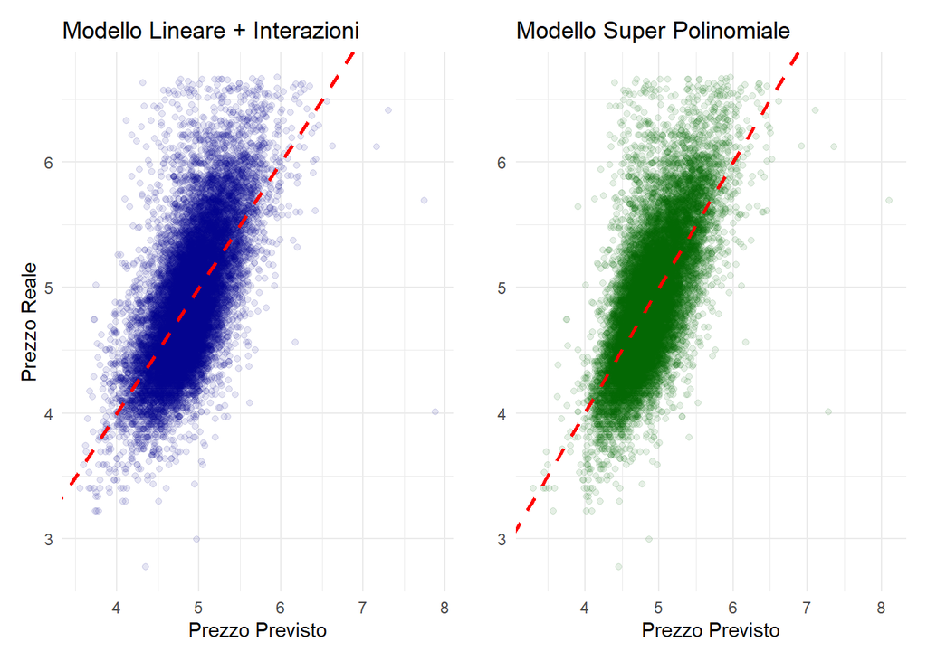

```r
# Preparazione dei dati per il grafico comparativo
df_confronto_base <- data.frame(
  Reale = modello_interazioni$model$log_price,
  Previsto = fitted(modello_interazioni),
  Modello = "Lineare con Interazioni"
)

df_confronto_super <- data.frame(
  Reale = modello_super$model$log_price,
  Previsto = fitted(modello_super),
  Modello = "Super Polinomiale"
)

# Generazione del Grafico Comparativo (Actual vs Predicted)
p_base <- ggplot(df_confronto_base, aes(x = Previsto, y = Reale)) +
  geom_point(alpha = 0.1, color = "darkblue") +
  geom_abline(intercept = 0, slope = 1, color = "red", linetype = "dashed", linewidth = 1) +
  theme_minimal() +
  labs(title = "Modello Lineare + Interazioni", x = "Prezzo Previsto", y = "Prezzo Reale")

p_super <- ggplot(df_confronto_super, aes(x = Previsto, y = Reale)) +
  geom_point(alpha = 0.1, color = "darkgreen") +
  geom_abline(intercept = 0, slope = 1, color = "red", linetype = "dashed", linewidth = 1) +
  theme_minimal() +
  labs(title = "Modello Super Polinomiale", x = "Prezzo Previsto", y = "")

# Visualizzazione affiancata
p_base + p_super
```

```r
# CONFRONTO TRA MODELLI

# Confronto dell'R-quadro Adattato (Penalizza leggermente la complessità)
cat("R-quadro Adj - Interazioni:", summary(modello_interazioni)$adj.r.squared, "\n")
```

```
## R-quadro Adj - Interazioni: 0.4333273
```

```r
cat("R-quadro Adj - Super Polinom:", summary(modello_super)$adj.r.squared, "\n\n")
```

```
## R-quadro Adj - Super Polinom: 0.4691314
```

```r
# Confronto AIC (Premia il fit, penalizza il numero di variabili)
cat("--- Criterio AIC (Valore MINORE vince) ---\n")
```

```
## --- Criterio AIC (Valore MINORE vince) ---
```

```r
AIC(modello_interazioni, modello_super)
```

```
##                     df      AIC
## modello_interazioni 16 17145.99
## modello_super       16 16035.53
```

```r
# Confronto BIC (penalizza fortemente i modelli troppo complessi --> ottimo contro l'overfitting)
cat("\n--- Criterio BIC (Valore MINORE vince) ---\n")
```

```
##
## --- Criterio BIC (Valore MINORE vince) ---
```

```r
BIC(modello_interazioni, modello_super)
```

```
##                     df      BIC
## modello_interazioni 16 17269.86
## modello_super       16 16159.40
```

Ho messo a confronto il modello log-lineare con interazioni spaziali con il modello polinomiale.

Tuttavia, in ambito econometrico, la scelta del modello ottimale non è dettata dalla sola minimizzazione dell’errore, ma deve bilanciare la capacità predittiva con l’**interpretabilità dei coefficienti**.

Il modello polinomiale, pur fittando meglio i dati, agisce come una ‘black-box’: le variabili al quadrato perdono di significato economico diretto, rendendo impossibile isolare gli effetti marginali specifici. Al contrario, il modello con interazioni permette di tradurre i coefficienti in reali dinamiche di mercato e comportamenti dei consumatori.

Pertanto, prediligendo il potere esplicativo rispetto a quello puramente predittivo , si conferma la scelta di adottare il modello log-lineare con interazioni.

### Validazione Out-of-Sample

```r
set.seed(123)

# SPLIT DEL DATASET (80% Train, 20% Test)
indice_train <- sample(1:nrow(df_final), size = 0.8 * nrow(df_final))

# Divisione dati
train_data <- df_final[indice_train, ]
test_data <- df_final[-indice_train, ]

# ADDESTRAMENTO
# Uso il mod con interazioni solo sull'80% dei dati
modello_train <- lm(log_price ~ accommodates + bedrooms + bathrooms +
                    host_is_superhost + review_scores_rating + log_reviews +
                    minimum_nights + availability_365 +
                    distanza_centro_km * room_type +
                    bathrooms:accommodates,
                    data = train_data)

# PREVISIONE SUL TEST SET
previsioni_log <- predict(modello_train, newdata = test_data)

# Riconverto le previsioni e i prezzi reali da Logaritmi a euro
previsioni_euro <- exp(previsioni_log)
prezzi_reali_euro <- test_data$price

# METRICHE DI ERRORE
# MAE (Mean Absolute Error): Quanto sbaglia in media, in Euro, per ogni annuncio
mae <- mean(abs(prezzi_reali_euro - previsioni_euro), na.rm = TRUE)

# RMSE (Root Mean Squared Error): Penalizza gli errori più grandi (es. se sbaglia di 200€ pesa molto)
rmse <- sqrt(mean((prezzi_reali_euro - previsioni_euro)^2, na.rm = TRUE))

# Risultati
cat("--- PERFORMANCE PREDITTIVA FUORI CAMPIONE ---\n")
```

```
## --- PERFORMANCE PREDITTIVA FUORI CAMPIONE ---
```

```r
cat("Dati di Test:", nrow(test_data), "appartamenti\n")
```

```
## Dati di Test: 3403 appartamenti
```

```r
cat("Errore Assoluto Medio (MAE):", round(mae, 2), "€ a notte\n")
```

```
## Errore Assoluto Medio (MAE): 48.21 € a notte
```

```r
cat("Errore Quadratico Medio (RMSE):", round(rmse, 2), "€ a notte\n")
```

```
## Errore Quadratico Medio (RMSE): 80.78 € a notte
```

Per verificare come si comporta il modello di fronte a dati nuovi, ho effettuato un test *Out-of-Sample*, addestrando l’algoritmo sull’80% dei dati e chiedendogli di prevedere il prezzo del restante 20% (3.403 appartamenti). Le previsioni logaritmiche sono state riconvertite in Euro per facilitare l’interpretazione.

I risultati mostrano un Errore Assoluto Medio (MAE) di **48.21 €** e un Errore Quadratico Medio (RMSE) di **80.78 €**.

Un errore medio di circa 48 € a notte è coerente con i limiti del dataset. Il modello, infatti, basa le sue previsioni su variabili “quantitative” (numero di posti letto, distanza dal centro, tipologia di stanza). Nel mercato reale di Airbnb, tuttavia, il prezzo finale è influenzato anche da fattori “qualitativi” invisibili ai dati (citati sopra)

La notevole distanza tra il MAE (**48.21 €**) e l’RMSE (**80.78 €**) conferma ulteriormente questa dinamica. L’RMSE penalizza maggiormente gli errori grandi: questo significa che il modello è mediamente preciso per gli appartamenti standard, ma commette errori più gravi (sottostimando o sovrastimando di molto) immobili di lusso o con prezzi fuori mercato. Per l’algoritmo, due case con 4 posti letto a 1 km dal Duomo dovrebbero avere lo stesso prezzo, ignorando che una potrebbe essere un attico di pregio e l’altra un seminterrato.

In conclusione, il modello si rivela utile per tracciare le regole base e l’influenza spaziale del mercato milanese, ma dimostra anche che il *pricing* nel settore turistico conserva una forte componente soggettiva ed estetica non modellizzabile con i soli dati strutturali.

```r
residui_finali <- residuals(modello_interazioni)

# Test di Jarque-Bera
cat("--- TEST DI NORMALITÀ DI JARQUE-BERA ---\n")
```

```
## --- TEST DI NORMALITÀ DI JARQUE-BERA ---
```

```r
jarque.bera.test(residui_finali)
```

```
##
##  Jarque Bera Test
##
## data:  residui_finali
## X-squared = 4113.8, df = 2, p-value < 2.2e-16
```

### Test di Jarque-Bera

Per verificare se gli errori del modello seguono una distribuzione normale, ho utilizzato il test di Jarque-Bera. Il test ha restituito un valore molto alto (4113.8) con un P-value quasi pari a zero, indicando che la normalità non è perfetta.

Tuttavia, questo risultato non invalida il modello, per due motivi:

1. **Campione grande:** Il test di Jarque-Bera è famoso per essere “troppo sensibile” quando si lavora con moli di dati molto grandi. Nel dataset, questa deviazione è dovuta semplicemente alla natura del mercato immobiliare milanese: la convivenza tra case molto economiche e attici extra-lusso genera grosse code che rendono impossibile ottenere una campana perfetta.
2. **Il Teorema del Limite Centrale:** Avere una curva degli errori perfettamente normale è un requisito fondamentale solo quando si hanno pochi dati a disposizione. Quando il campione è molto ampio, grazie alle proprietà asintotiche del Teorema del Limite Centrale si conclude che indipendentemente dalla forma esatta degli errori, le stime del modello convergono al parametro della popolazione.

### ANALISI IN COMPONENTI PRINCIPALI

```r
# Creo un dataset idoneo alla PCA
df_pca_prep <- df_final %>%
  mutate(
    # Da Distanza a Vicinanza: Sottraggo il valore corrente al valore massimo
    vicinanza_centro = max(distanza_centro_km, na.rm = TRUE) - distanza_centro_km,

    # Da Notti Minime a Flessibilità
    flessibilita_soggiorno = max(minimum_nights, na.rm = TRUE) - minimum_nights

  ) %>%
  select(
    accommodates, bedrooms, bathrooms,         # Capacità Strutturale
    review_scores_rating, log_reviews,         # Qualità e Popolarità
    vicinanza_centro, flessibilita_soggiorno   # Variabili allineate
  )

# Controllo
summary(df_pca_prep)
```

```
##   accommodates       bedrooms        bathrooms     review_scores_rating
##  Min.   : 1.000   Min.   : 0.000   Min.   : 0.00   Min.   :0.000
##  1st Qu.: 2.000   1st Qu.: 1.000   1st Qu.: 1.00   1st Qu.:4.670
##  Median : 4.000   Median : 1.000   Median : 1.00   Median :4.830
##  Mean   : 3.463   Mean   : 1.204   Mean   : 1.15   Mean   :4.727
##  3rd Qu.: 4.000   3rd Qu.: 1.000   3rd Qu.: 1.00   3rd Qu.:4.950
##  Max.   :16.000   Max.   :10.000   Max.   :21.00   Max.   :5.000
##   log_reviews    vicinanza_centro flessibilita_soggiorno
##  Min.   :0.000   Min.   :0.000    Min.   : 0.00
##  1st Qu.:1.609   1st Qu.:5.934    1st Qu.:28.00
##  Median :2.890   Median :6.944    Median :29.00
##  Mean   :2.797   Mean   :6.765    Mean   :28.19
##  3rd Qu.:4.025   3rd Qu.:7.878    3rd Qu.:29.00
##  Max.   :7.241   Max.   :9.691    Max.   :29.00
```

```r
# ESECUZIONE DELLA PCA
# scale = TRUE standardizza le unità di misura (km, notti, voti)
pca_result <- prcomp(df_pca_prep, center = TRUE, scale. = TRUE)

cat("--- RIASSUNTO COMPONENTI PRINCIPALI ---\n")
```

```
## --- RIASSUNTO COMPONENTI PRINCIPALI ---
```

```r
summary(pca_result)
```

```
## Importance of components:
##                           PC1    PC2    PC3    PC4    PC5     PC6     PC7
## Standard deviation     1.4641 1.0583 1.0328 0.9996 0.9061 0.73678 0.55386
## Proportion of Variance 0.3062 0.1600 0.1524 0.1427 0.1173 0.07755 0.04382
## Cumulative Proportion  0.3062 0.4662 0.6186 0.7613 0.8786 0.95618 1.00000
```

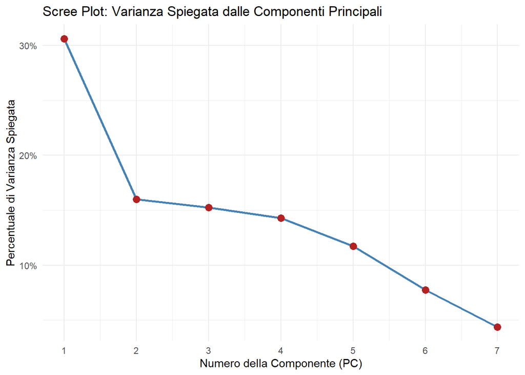

```r
# Scree Plot
varianza_spiegata <- pca_result$sdev^2 / sum(pca_result$sdev^2)
df_varianza <- data.frame(PC = 1:length(varianza_spiegata), Varianza = varianza_spiegata)

ggplot(df_varianza, aes(x = PC, y = Varianza)) +
  geom_line(color = "steelblue", linewidth = 1) +
  geom_point(color = "firebrick", size = 3) +
  scale_x_continuous(breaks = 1:7) +
  scale_y_continuous(labels = scales::percent_format(accuracy = 1)) +
  theme_minimal() +
  labs(title = "Scree Plot: Varianza Spiegata dalle Componenti Principali",
       x = "Numero della Componente (PC)", y = "Percentuale di Varianza Spiegata")
```

```r
#  MATRICE DEI LOADINGS (a 3 decimali)
loadings_matrix <- round(pca_result$rotation[, 1:5], 3)
cat("\n--- MATRICE DEI LOADINGS (PESI DELLE VARIABILI) ---\n")
```

```
##
## --- MATRICE DEI LOADINGS (PESI DELLE VARIABILI) ---
```

```r
print(loadings_matrix)
```

```
##                           PC1    PC2    PC3    PC4    PC5
## accommodates            0.571 -0.051 -0.002  0.086  0.001
## bedrooms                0.611  0.006  0.070  0.015 -0.026
## bathrooms               0.545  0.011  0.021 -0.083  0.020
## review_scores_rating   -0.006  0.686  0.390  0.094  0.606
## log_reviews             0.027  0.718 -0.312  0.050 -0.620
## vicinanza_centro        0.047  0.102 -0.666 -0.610  0.406
## flessibilita_soggiorno  0.019 -0.043 -0.549  0.776  0.288
```

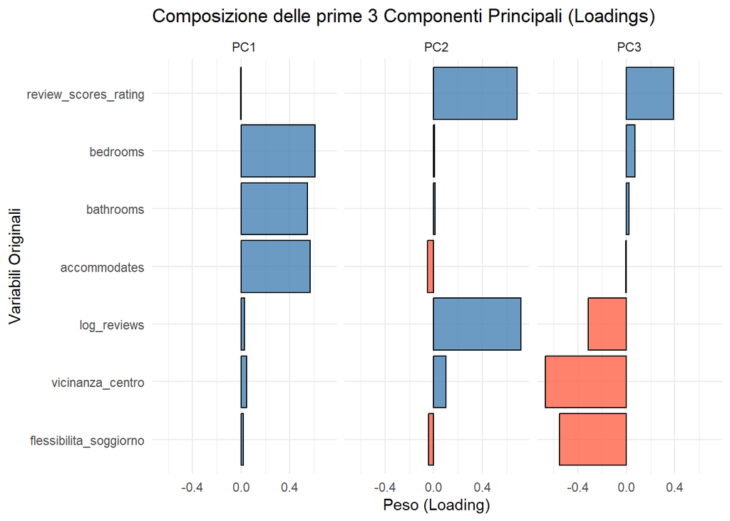

```r
# LOADINGS
df_loadings <- as.data.frame(pca_result$rotation[, 1:5])
df_loadings$Variabile <- rownames(df_loadings)

df_loadings_long <- df_loadings %>%
  pivot_longer(cols = PC1:PC5, names_to = "Componente", values_to = "Peso")

# Grafico a barre per visualizzare cosa c'è dentro le prime 3 PC
plot_loadings <- ggplot(df_loadings_long %>% filter(Componente %in% c("PC1", "PC2", "PC3")),
                        aes(x = reorder(Variabile, Peso), y = Peso, fill = Peso > 0)) +
  geom_bar(stat = "identity", color = "black", alpha = 0.8) +
  coord_flip() + # Mettiamo le barre in orizzontale
  facet_wrap(~ Componente) +
  scale_fill_manual(values = c("tomato", "steelblue"), guide = "none") +
  theme_minimal() +
  labs(title = "Composizione delle prime 3 Componenti Principali (Loadings)",
       x = "Variabili Originali",
       y = "Peso (Loading)")

# Grafico Loadings
print(plot_loadings)
```

### Selezione del Sottospazio Vettoriale e Interpretazione Economica delle Componenti

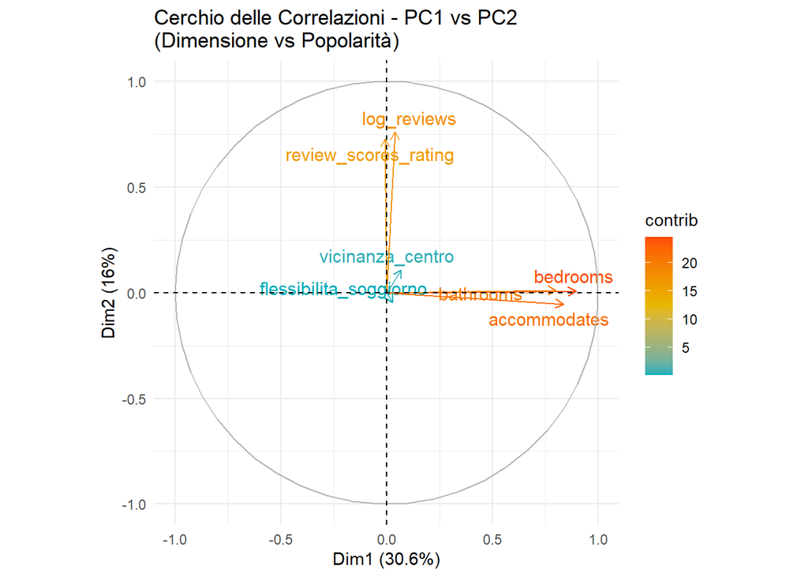

```r
# BIPLOT: PC1 vs PC2 (Dimensione vs Popolarità)
plot_pca_1_2 <- fviz_pca_var(pca_result,
                             axes = c(1, 2), # Assi 1 e 2
                             col.var = "contrib",
                             gradient.cols = c("#00AFBB", "#E7B800", "#FC4E07"),
                             repel = TRUE,
                             title = "Cerchio delle Correlazioni - PC1 vs PC2\n(Dimensione vs Popolarità)") +
  theme_minimal()

print(plot_pca_1_2)
```

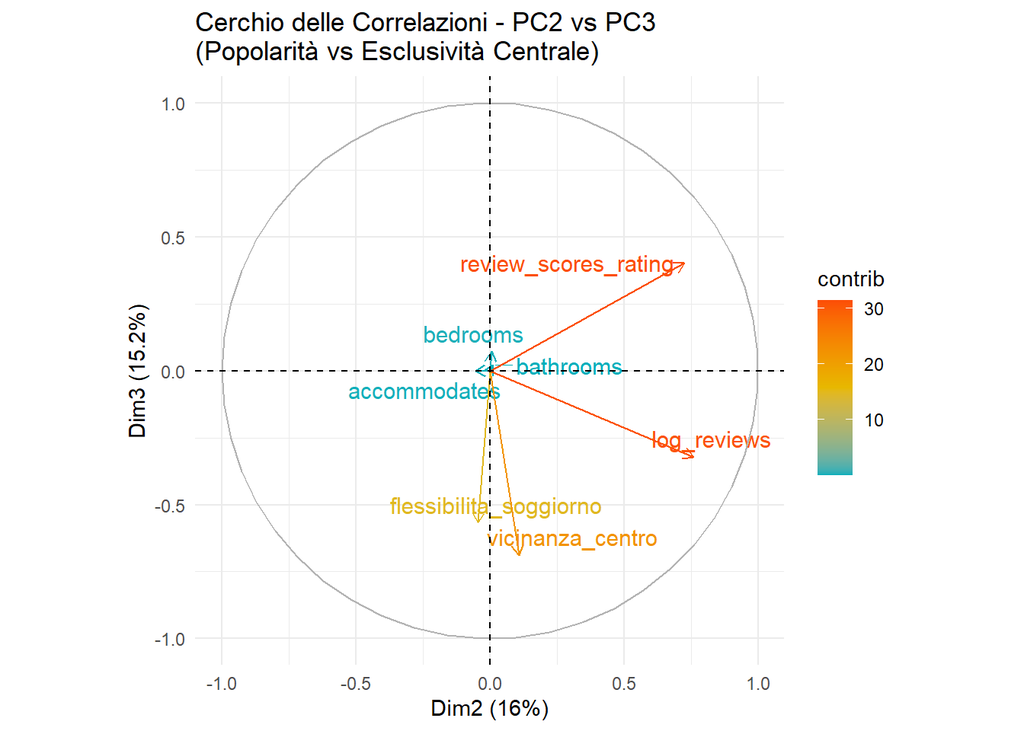

```r
# BIPLOT: PC2 vs PC3 (Popolarità vs Esclusività)
plot_pca_2_3 <- fviz_pca_var(pca_result,
                             axes = c(2, 3), # Scegliamo PC2 e PC3
                             col.var = "contrib",
                             gradient.cols = c("#00AFBB", "#E7B800", "#FC4E07"),
                             repel = TRUE,
                             title = "Cerchio delle Correlazioni - PC2 vs PC3\n(Popolarità vs Esclusività Centrale)") +
  theme_minimal()

print(plot_pca_2_3)
```

### Nota Metodologica sulle Scelte di Visualizzazione della PCA

- **Esclusione degli Scores Individuali:** Nei grafici spaziali delle componenti ho scelto di omettere gli *scores* (ovvero il posizionamento dei singoli appartamenti), focalizzando l’output esclusivamente sul grafico dei vettori delle variabili. Data l’elevata numerosità del dataset. La proiezione dei soli vettori consente di analizzare le correlazioni (angoli) e i pesi delle variabili originali rispetto alle PC.
- **Selezione delle Coppie di Componenti:** Essendo PC4 e PC5 dei meri correttori a bassa varianza (utili solo per la successiva PCR), l’analisi grafica si concentra sulle coppie **PC1 vs PC2** (Dimensione vs Popolarità) e **PC2 vs PC3** (Popolarità vs Esclusività Centrale). Così da isolare visivamente i driver che governano i prezzi su Airbnb a Milano, tralasciando combinazioni meno interpretabili.

### MODELLO PCR

```r
# COSTRUZIONE DEL DATASET PCR
# Aggiungo il log_price, le variabili categoriche e le prime 5 PC estratte
df_pcr_definitivo <- df_final %>%
  select(log_price, room_type, host_is_superhost) %>%
  bind_cols(as.data.frame(pca_result$x[, 1:5]))

# STIMA DEL MODELLO PCR
modello_pcr_definitivo <- lm(log_price ~ PC1 + PC2 + PC3 + PC4 + PC5 +
                               room_type + host_is_superhost,
                             data = df_pcr_definitivo)

summary(modello_pcr_definitivo)
```

```
##
## Call:
## lm(formula = log_price ~ PC1 + PC2 + PC3 + PC4 + PC5 + room_type +
##     host_is_superhost, data = df_pcr_definitivo)
##
## Residuals:
##     Min      1Q  Median      3Q     Max
## -4.6527 -0.2654 -0.0363  0.2290  2.2811
##
## Coefficients:
##                        Estimate Std. Error  t value Pr(>|t|)
## (Intercept)            4.913088   0.004104 1197.265   <2e-16 ***
## PC1                    0.153370   0.002132   71.937   <2e-16 ***
## PC2                   -0.056929   0.003206  -17.756   <2e-16 ***
## PC3                   -0.133419   0.002991  -44.601   <2e-16 ***
## PC4                   -0.098841   0.003085  -32.043   <2e-16 ***
## PC5                    0.177985   0.003407   52.238   <2e-16 ***
## room_typePrivate room -0.210957   0.011267  -18.723   <2e-16 ***
## room_typeShared room  -0.938125   0.062086  -15.110   <2e-16 ***
## host_is_superhostTRUE -0.009567   0.007100   -1.347    0.178
## ---
## Signif. codes:  0 '***' 0.001 '**' 0.01 '*' 0.05 '.' 0.1 ' ' 1
##
## Residual standard error: 0.4014 on 17005 degrees of freedom
## Multiple R-squared:  0.4303, Adjusted R-squared:  0.4301
## F-statistic:  1606 on 8 and 17005 DF,  p-value: < 2.2e-16
```

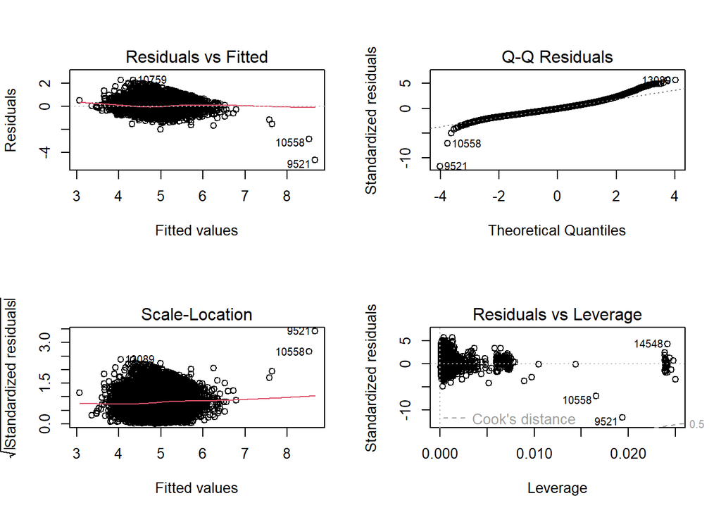

```r
par(mfrow = c(2, 2))

plot(modello_pcr_definitivo)
```

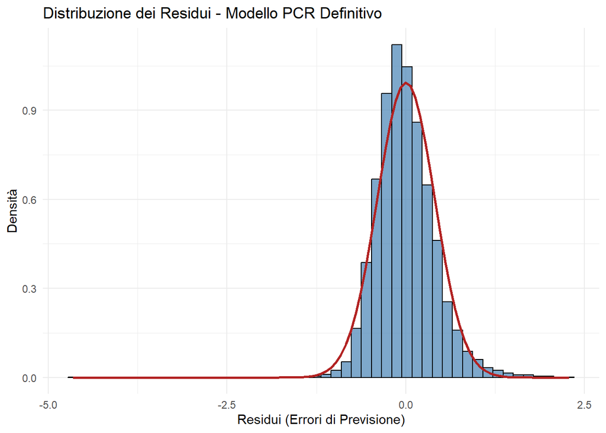

```r
par(mfrow = c(1, 1))


# ISTOGRAMMA RESIDUI
df_pcr_definitivo$residui_pcr <- residuals(modello_pcr_definitivo)

plot_residui_pcr <- ggplot(df_pcr_definitivo, aes(x = residui_pcr)) +
  geom_histogram(aes(y = after_stat(density)), bins = 50, fill = "steelblue", color = "black", alpha = 0.7) +
  stat_function(fun = dnorm,
                args = list(mean = mean(df_pcr_definitivo$residui_pcr),
                            sd = sd(df_pcr_definitivo$residui_pcr)),
                color = "firebrick", linewidth = 1) +
  theme_minimal() +
  labs(title = "Distribuzione dei Residui - Modello PCR Definitivo",
       x = "Residui (Errori di Previsione)", y = "Densità")

print(plot_residui_pcr)
```

### Analisi dei Residui PCR

Osservando l’istogramma della densità dei residui sovrapposto alla curva normale teorica (in rosso), si nota una distribuzione simmetrica e perfettamente centrata sullo zero.

1. **Residuals vs Fitted:** La nuvola di punti si distribuisce uniformemente in una banda orizzontale attorno allo zero, confermando la linearità della relazione e l’assenza di pattern non lineari omessi.
2. **Normal Q-Q:** I quantili standardizzati si allineano in modo quasi perfetto lungo la bisettrice, deviando solo nelle code estreme della distribuzione.
3. **Scale-Location:** La linea di tendenza si mantiene prevalentemente piatta, suggerendo che l’assunzione di omosedasticità non è severamente violata.
4. **Residuals vs Leverage:** Nessuna singola osservazione supera le soglie critiche della Distanza di Cook, dimostrando che il modello non è distorto da *outlier* ad alta leva.

### Il Trade-Off tra Previsione e Interpretabilità

La stima del modello PCR addestrato sulle 5 Componenti Principali, sulla tipologia di stanza e sullo status dell’host presenta parametri altamente significativi per tutti i vettori latenti. In particolare, la PC1 (Indice di Capacità Strutturale) mostra un coefficiente positivo (0.153), confermando che la grandezza e la capienza dell’immobile rappresentano la prima forza trainante del prezzo logaritmico.

Nonostante il modello PCR gode della quasi totale assenza di multicollinearità tra i regressori numerici, l’informazione processata dall’algoritmo non restituisce un vantaggio predittivo. L’*Adjusted R-squared* del modello PCR si assesta infatti a **0.4301**, risultando lievemente inferiore a quello ottenuto dal modello con interazioni (**0.4333**).

Questo risultato dimostra che la perdita di informazione dovuta alla compressione delle variabili non è compensata da un incremento dell’accuratezza predittiva. Al contrario, il modello con interazioni non solo performa meglio nel minimizzare gli errori di previsione, ma ha il vantaggio della **totale interpretabilità economica**.